# Connectome-constrained atrophy in AD and FTD syndromes

Schaefer 100/200/400; HCP SC and FC; communication models vs distance; five null models

2026-11-21

# 1 Summary

**Question.** Does cortical atrophy in AD and the FTD syndromes follow the connectome, or is it explained by spatial proximity? Which communication model on the structural connectome (SC) predicts it best, and does any beat a distance-only baseline?

**Data.** Seven group-level DBM atrophy maps (AD, MCI from ADNI; PD from PPMI; pooled FTD, bvFTD, svPPA, nfvPPA from NIFD); HCP SC and FC; Schaefer 100/200/400 (400 primary). **No DLB map exists in the two Zenodo records; none was substituted.**

**Main findings (Schaefer-400; all hold at 100 and 200 unless stated).**

1. **No communication model beats distance.** A distance-only kernel exp(−d/λ) predicts each region’s atrophy from other regions’ atrophy best in every syndrome (r = 0.57–0.83). Its fitted length scale is ~3.6 mm, so it measures how *smooth* the map is (a parcel resembles its immediate neighbours); it does not mean that disease spreads only locally. The AD pattern is distributed (40 most atrophic parcels in 22 separate clusters). In AD, bvFTD and pooled FTD the best single predictor of a parcel’s atrophy is the atrophy at its mirror location in the other hemisphere (r = 0.81, 0.81, 0.85). The best SC models (one-step SC, search information, heat kernel) reach r = 0.44–0.72. Zero of 49 model-vs-distance comparisons favour a model at FDR < 0.05 at any resolution; giving each model one fitted exponent only produces ties (Δr ≤ 0.04, n.s.).
2. **The best “diffusion” is one step.** The network diffusion kernel’s fitted β sits at the low end of its grid, i.e. it collapses to direct neighbours. Diffusion efficiency (1/MFPT) is dominated by node strength and gives negative or near-zero r; it should not be read as a spreading model.
3. **SC effects are mostly geometry.** Degree-preserving rewiring makes every SC model look significant (35/35 tests); geometry-preserving rewiring makes almost none significant (2/35). The exception is **bvFTD**, where path-based SC models (shortest-path efficiency, navigation) and long-range heat/communicability beat the geometry-preserving null. Atrophy in bvFTD and AD is also smoother on the real SC than on geometry-matched rewired SCs (graph Dirichlet energy, p = 0.001).
4. **FC carries signal beyond distance, mainly in FTD.** FC’s partial correlation with atrophy beyond the distance kernel: bvFTD 0.23, pooled FTD 0.18, svPPA 0.13, AD 0.11 (spin p ≤ 0.017). Using only connections longer than 30 mm, FC predicts bvFTD (r = 0.51), FTD (0.44) and svPPA (0.29) atrophy, significant under all three spatial nulls at 400 parcels and under the variogram null at 100, 200 and 400; in AD the long-range FC signal is weak (r ≈ 0.09).
5. **Epicentres.** AD: left and right medial/anterior temporal parcels. bvFTD: orbitofrontal cortex and **anterior insula** (bilateral Cont_PFCv_1 and LH FrOperIns_3 in the top 5; the expected check passes). svPPA: left temporal pole. nfvPPA: left frontal operculum, FEF/premotor and SMA. When the voxel map is mirrored left–right, nfvPPA’s epicentres and most of svPPA’s lose rank (left-specific), whereas bvFTD’s and AD’s keep it (not hemisphere-specific).
6. **Null models decide significance.** Parcel-level spins make maps rougher at short range than the real map (short-range variogram ≈ 1.9× empirical), so they flag 27/42 model fits as significant; variogram-matched surrogates flag 3/42 and Moran spectral randomisation 11/42. Conclusions above rest on effects that survive the stricter nulls.
7. **Eigenmodes.** Geometric (cortical-surface) eigenmodes reconstruct AD and MCI atrophy better than spatially matched surrogates; FC harmonics do so for bvFTD and pooled FTD. SC harmonics beat degree-rewired SCs but not geometry-rewired ones (except in nfvPPA).
8. **Asymmetry.** Comparing each left region with the identical mirrored right region, AD, MCI and bvFTD are symmetric; svPPA (84% of the most atrophic locations left-dominant, sign test p < 0.001) and nfvPPA (67%, p = 0.008) are left-lateralised. The left anterior-insula peaks in the raw bvFTD (and, partly, AD) maps are largely an atlas artefact.
9. **MCI** has the AD topography (r = 0.80) at about two-thirds of its amplitude, with medial temporal and posterior cingulate/precuneus epicentres; network effects follow AD but are weaker and do not survive the stricter nulls.
10. **Similarity.** AD resembles MCI (r = 0.80) and, less, svPPA (0.48) and bvFTD (0.31); all FTD maps are mutually similar (spin FDR < 0.05; inflated by a shared NIFD control group); PD is unrelated to the others. Highly FC-connected hubs are *less* atrophic in bvFTD and pooled FTD (ρ ≈ −0.62, FDR q = 0.007); SC strength shows no association that survives FDR.

**Interpretation.** At group level, the AD map is captured by its own spatial smoothness and bilateral symmetry; neither structural routes nor functional networks add much beyond that in this cortical-only analysis (the hippocampus, which links the medial temporal and posterior cingulate clusters, is not included). bvFTD (and pooled FTD, svPPA) additionally follow long-range *functional* networks, with a smaller structural-topology effect in bvFTD. Because degree-only rewiring and spin nulls overstate network effects, claims of “connectome-shaped atrophy” need geometry-aware nulls and a distance baseline.

**Novelty.** A systematic search found no prior head-to-head comparison of SC communication models against a distance baseline across AD and the FTD variants with spatial and rewiring nulls (see “Novelty check”). The bvFTD neighbour-atrophy result replicates Shafiei et al. 2023 with an independent connectome and atlas.

**connectomeR.** The 0.2.0 tarball was never supplied. All needed functions were written and validated against bctpy, netneurotools and neuromaps; the network functions form the package `pkg/netcomm`, which passes `R CMD check` (0 errors, 0 warnings, 0 notes) and is ready to merge into connectomeR 0.3.0. connectomeR itself could not be updated or checked.

**Two data caveats.** The three FTD-variant maps are on an unusual scale (about ±1.5, vs ±16 for pooled FTD; the MINC copies agree); all analyses are scale-invariant, but the values should not be read as t until the authors confirm what was deposited. The template and atlas differ (ICBM 2009c symmetric vs FSL MNI152), see Limitations.

# 2 Data

```r
source("R/step1.R")
rec <- lapply(c("7392621", "10383493"), function(r)
  jsonlite::fromJSON(file.path(paths$zenodo, sprintf("record_%s.json", r))))
files <- do.call(rbind, lapply(rec, function(d) {
  f <- d$files
  f <- f[grepl("Tstat.*\\.nii$", f$key), ]
  data.frame(record = d$doi, file = f$key, md5 = sub("md5:", "", f$checksum))
}))
md5_local <- unname(tools::md5sum(file.path(paths$zenodo, files$file)))
files$md5_ok <- md5_local == files$md5
files
```

| record | file | md5 | md5_ok |
| --- | --- | --- | --- |
| 10.5281/zenodo.7392621 | MCI_vs_Control_Tstat_Map_icbm152_nlin_sym.nii | 792f64ce9b4bb866a178584d32b11786 | TRUE |
| 10.5281/zenodo.7392621 | FTD_vs_Control_Tstat_Map_icbm152_nlin_sym.nii | 281f2cea086d44790be8ccbff1b5b52e | TRUE |
| 10.5281/zenodo.7392621 | PD_vs_Control_Tstat_Map_icbm152_nlin_sym.nii | 6d6c9cd82970008fa0f6949265307119 | TRUE |
| 10.5281/zenodo.7392621 | AD_vs_Control_Tstat_Map_icbm152_nlin_sym.nii | 7177581f96a51ef3612ffcebb48dc225 | TRUE |
| 10.5281/zenodo.10383493 | svPPA_vs_Control_Tstat_Map_icbm152_nlin_sym.nii | 41af1d99282035275ff675eb4405a1b8 | TRUE |
| 10.5281/zenodo.10383493 | pnfaPPA_vs_Control_Tstat_Map_icbm152_nlin_sym.nii | e057bf0aaa574d16d36de140f25ae282 | TRUE |
| 10.5281/zenodo.10383493 | bvFTD_vs_Control_Tstat_Map_icbm152_nlin_sym.nii | 95a7b7aeced5887154a6cb3f7f500e59 | TRUE |

```r
stopifnot(all(files$md5_ok))
dlb_mentioned <- vapply(rec, function(d) grepl("dlb|lewy", tolower(jsonlite::toJSON(d))), TRUE)
dlb_mentioned
```

```
## [1] FALSE FALSE
```

**Atrophy maps.** Voxel-wise deformation-based morphometry (DBM) t-maps, patients vs matched controls, on the ICBM152 2009c nonlinear symmetric template.

- Zenodo 10.5281/zenodo.7392621 (Dadar, 2022; CC-BY-4.0): AD and MCI (ADNI), PD (PPMI), pooled FTD (NIFD). The record cites: Dadar M, et al. *White matter hyperintensities are associated with grey matter atrophy and cognitive decline in Alzheimer’s disease and frontotemporal dementia.* Neurobiol Aging 2022;111:54–63.
- Zenodo 10.5281/zenodo.10383493 (Dadar & Metz, 2023; CC-BY-4.0): bvFTD, svPPA, nfvPPA (filed as `pnfaPPA`), all NIFD. The record cites Dadar et al. 2022 (above) and Metz A, et al. *Brain atrophy and white matter hyperintensities in frontotemporal dementia variants and their impact on cognition.* CCNA Partners Forum and Science Days, March 2024 (conference presentation).
- Neither record has a DLB map or a link to one (`dlb_mentioned` above is `FALSE` for both).

**Connectomes.** HCP group-level structural (SC) and functional (FC) matrices for Schaefer-100/200/400 from the ENIGMA toolbox (Larivière et al., Nat Methods 2021), commit `b08974b`. Only the data files were read.

**Atlas.** Schaefer et al. 2018 (Cereb Cortex), 7-network order, FSL MNI152 1 mm volumes and label tables from CBIG, commit `634f676`.

`scripts/00_get_data.sh` reproduces every download and checks the md5 sums.

## 2.1 Image grids

```r
s1 <- run_step1(write = TRUE)
g <- attr(s1, "grids")
atlas_g <- nifti_grid(file.path(paths$schaefer, "Schaefer2018_400Parcels_7Networks_order_FSLMNI152_1mm.nii.gz"))
grid_tab <- rbind(
  do.call(rbind, lapply(names(g), function(s) data.frame(
    image = paste0(s, " t-map"), template = "ICBM152 2009c nlin sym",
    dim = paste(g[[s]]$dim, collapse = "×"), voxel_mm = paste(g[[s]]$pixdim, collapse = "×"),
    orientation = g[[s]]$orientation, origin_mm = paste(g[[s]]$affine[1:3, 4], collapse = ", ")))),
  data.frame(image = "Schaefer atlas (all k)", template = "FSL MNI152 (nlin 6th gen)",
             dim = paste(atlas_g$dim, collapse = "×"), voxel_mm = paste(atlas_g$pixdim, collapse = "×"),
             orientation = atlas_g$orientation, origin_mm = paste(atlas_g$affine[1:3, 4], collapse = ", ")))
grid_tab
```

| image | template | dim | voxel_mm | orientation | origin_mm |
| --- | --- | --- | --- | --- | --- |
| AD t-map | ICBM152 2009c nlin sym | 193×229×193 | 1×1×1 | RAS | -96, -132, -78 |
| MCI t-map | ICBM152 2009c nlin sym | 193×229×193 | 1×1×1 | RAS | -96, -132, -78 |
| PD t-map | ICBM152 2009c nlin sym | 193×229×193 | 1×1×1 | RAS | -96, -132, -78 |
| FTD t-map | ICBM152 2009c nlin sym | 193×229×193 | 1×1×1 | RAS | -96, -132, -78 |
| bvFTD t-map | ICBM152 2009c nlin sym | 193×229×193 | 1×1×1 | RAS | -96, -132, -78 |
| svPPA t-map | ICBM152 2009c nlin sym | 193×229×193 | 1×1×1 | RAS | -96, -132, -78 |
| nfvPPA t-map | ICBM152 2009c nlin sym | 193×229×193 | 1×1×1 | RAS | -96, -132, -78 |
| Schaefer atlas (all k) | FSL MNI152 (nlin 6th gen) | 182×218×182 | 1×1×1 | LAS | 90, -126, -72 |

All seven t-maps share one 1 mm grid (`all(attr(s1, "same_grid"))` = TRUE). The atlas is on a different grid and orientation (LAS vs RAS). It was resampled to the t-map grid by nearest neighbour through world coordinates; the t-maps were not resampled. The resampling code (`R/parcellate.R`) returns the atlas unchanged when resampled to its own grid, and gives a result identical voxel for voxel to an independent nibabel implementation on the t-map grid (checked during development for Schaefer-400; all 400 labels survive).

The two templates are both “MNI” but not identical (2009c symmetric vs FSL 6th generation). No transform between them was applied; the residual misregistration is a few millimetres, which matters little at parcel level but adds to boundary blurring.

## 2.2 Label order

```r
label_checks <- do.call(rbind, lapply(resolutions, function(k) {
  info <- read_schaefer_labels(k) # stops with an error if any check fails
  cen <- read.csv(sprintf("data/sphere_centroids_schaefer%d.csv", k))
  data.frame(parcels = k, CBIG_LUT_ids_1toN = TRUE, CBIG_eq_ENIGMA_SC = TRUE,
             CBIG_eq_ENIGMA_FC = TRUE, CBIG_eq_CBIG_centroids = TRUE,
             fsa5_annot_eq_ENIGMA = identical(cen$label, info$label))
}))
label_checks
```

| parcels | CBIG_LUT_ids_1toN | CBIG_eq_ENIGMA_SC | CBIG_eq_ENIGMA_FC | CBIG_eq_CBIG_centroids | fsa5_annot_eq_ENIGMA |
| --- | --- | --- | --- | --- | --- |
| 100 | TRUE | TRUE | TRUE | TRUE | TRUE |
| 200 | TRUE | TRUE | TRUE | TRUE | TRUE |
| 400 | TRUE | TRUE | TRUE | TRUE | TRUE |

The CBIG label table, the ENIGMA SC and FC label files, the CBIG centroid table and the ENIGMA fsaverage5 annotation all list the same labels in the same order at 100, 200 and 400 parcels.

## 2.3 Connectome matrices

```r
read_mat <- function(type, k) {
  X <- as.matrix(read.csv(file.path(paths$enigma_mat, sprintf("%sMatrix_ctx_schaefer_%d.csv", type, k)), header = FALSE))
  dimnames(X) <- NULL; X
}
mat_tab <- do.call(rbind, lapply(resolutions, function(k) do.call(rbind, lapply(c("struc", "func"), function(ty) {
  X <- read_mat(ty, k); u <- X[upper.tri(X)]
  data.frame(matrix = ifelse(ty == "struc", "SC", "FC"), parcels = k, symmetric = isSymmetric(X),
             diag_zero = all(diag(X) == 0), negative_edges = sum(u < 0), zero_edges = sum(u == 0),
             positive_edges = sum(u > 0), density = round(mean(u != 0), 3),
             min = signif(min(u), 3), max = signif(max(u), 3))
}))))
mat_tab
```

| matrix | parcels | symmetric | diag_zero | negative_edges | zero_edges | positive_edges | density | min | max |
| --- | --- | --- | --- | --- | --- | --- | --- | --- | --- |
| SC | 100 | TRUE | TRUE | 1 | 3842 | 1107 | 0.224 | -0.212 | 11.70 |
| FC | 100 | TRUE | TRUE | 0 | 46 | 4904 | 0.991 | 0.000 | 1.42 |
| SC | 200 | TRUE | TRUE | 8 | 17489 | 2403 | 0.121 | -1.920 | 11.20 |
| FC | 200 | TRUE | TRUE | 0 | 386 | 19514 | 0.981 | 0.000 | 1.28 |
| SC | 400 | TRUE | TRUE | 14 | 74823 | 4963 | 0.062 | -1.760 | 10.60 |
| FC | 400 | TRUE | TRUE | 0 | 2363 | 77437 | 0.970 | 0.000 | 1.34 |

The SC matrices contain 1, 8, 14 negative edges (unique, upper triangle; twice as many entries in the full matrix) at 100, 200 and 400 parcels. In Step 2 they are set to 0 (`zero_negative()` in `R/setup.R`, a stand-in for `connectomeR::handle_negative()`). The FC matrices have no negative values; their minimum is 0, so they appear to have been thresholded upstream.

## 2.4 Sphere centroids for the spin test

Parcel centroids on the fsaverage5 sphere were computed from the ENIGMA files (`surfaces/fsa5_sphere_{lh,rh}.gii`, `permutation_testing/annot/fsa5_{lh,rh}_schaefer_*.annot`; note the annot files are under `enigmatoolbox/permutation_testing/`, not `datasets/permutation_testing/`). Because `connectomeR/inst/validation/annot_centroids.py` was not available, `scripts/annot_centroids.py` reimplements the usual method (Vasa et al. 2018): the mean of each parcel’s sphere vertices, snapped to the nearest vertex. The snapped vertex was the nearest vertex overall for 400/400 parcels. The spins built on these centroids were validated against neuromaps (see “Validation of the new functions”); the file should still be compared with the package script.

# 3 Parcellation and coverage

Parcel value = mean t over the parcel’s voxels on the t-map grid that have a finite, non-zero t (the maps are 0 outside their brain mask). Coverage = that voxel count divided by the parcel’s voxel count on the t-map grid. Atrophy is defined as −t.

```r
cov400 <- s1[["400"]]$coverage
cov_summary <- do.call(rbind, lapply(names(s1), function(k) {
  cv <- s1[[k]]$coverage
  data.frame(parcels = as.integer(k), min_coverage = round(min(cv$coverage_min), 3),
             median_coverage = round(median(cv$coverage_min), 3),
             parcels_below_50pct = sum(!cv$included),
             coverage_identical_across_maps = all(apply(cv[, grep("^coverage_[A-Za-z]", names(cv))], 1, function(r) diff(range(r)) == 0)))
}))
cov_summary
```

| parcels | min_coverage | median_coverage | parcels_below_50pct | coverage_identical_across_maps |
| --- | --- | --- | --- | --- |
| 100 | 0.885 | 0.999 | 0 | TRUE |
| 200 | 0.874 | 1.000 | 0 | TRUE |
| 400 | 0.771 | 1.000 | 0 | TRUE |

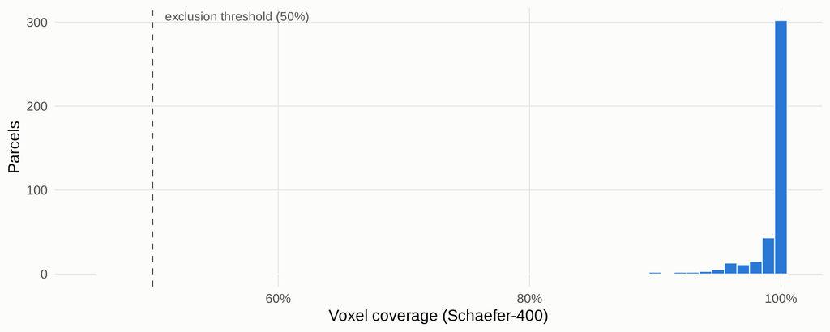

```r
ggplot(cov400, aes(coverage_min)) +
  geom_histogram(binwidth = 0.01, fill = col_main, colour = "#fcfcfb", linewidth = 0.3) +
  geom_vline(xintercept = 0.5, linetype = 2, colour = "#52514e") +
  annotate("text", x = 0.51, y = Inf, label = "exclusion threshold (50%)", hjust = 0, vjust = 1.5, size = 3, colour = "#52514e") +
  scale_x_continuous(limits = c(0.45, 1.005), labels = scales::percent) +
  labs(x = "Voxel coverage (Schaefer-400)", y = "Parcels")
```

```r
cov400 %>% arrange(coverage_min) %>% head(8) %>%
  transmute(label, n_vox_native, n_vox_grid, coverage = round(coverage_min, 3))
```

| label | n_vox_native | n_vox_grid | coverage |
| --- | --- | --- | --- |
| 7Networks_LH_Vis_15 | 4087 | 4087 | 0.771 |
| 7Networks_RH_SalVentAttn_Med_8 | 1314 | 1314 | 0.887 |
| 7Networks_RH_Cont_Par_4 | 1395 | 1395 | 0.897 |
| 7Networks_RH_Default_PFCdPFCm_11 | 3622 | 3622 | 0.901 |
| 7Networks_LH_SomMot_34 | 1836 | 1836 | 0.918 |
| 7Networks_RH_SomMot_21 | 1435 | 1435 | 0.923 |
| 7Networks_RH_SomMot_40 | 1156 | 1156 | 0.930 |
| 7Networks_LH_Default_PFC_18 | 1905 | 1905 | 0.932 |

No parcel falls below 50% coverage at any resolution, so **no parcels were excluded**. The least-covered parcels lie at the edge of the t-map brain mask (occipital pole, LH_Vis_15, 77%; then parcels at the dorsal vertex, 89–93%).

Outputs: `data/parcellated_atrophy_schaefer{100,200,400}.csv`, one row per parcel, with label, hemisphere, network, CBIG MNI centroid, coverage, an `included` flag and one atrophy column (−mean t) per syndrome.

# 4 Sanity checks

```r
a400 <- s1[["400"]]$atrophy
syn <- names(syndromes)
top_tab <- function(s, n = 10) a400 %>% arrange(desc(.data[[s]])) %>% head(n) %>%
  transmute(rank = row_number(), label = sub("7Networks_", "", label), x = mni_x, y = mni_y, z = mni_z, atrophy = round(.data[[s]], 2))
```

**AD, top 10 parcels (Schaefer-400):**

```r
top_tab("AD")
```

| rank | label | x | y | z | atrophy |
| --- | --- | --- | --- | --- | --- |
| 1 | RH_Limbic_TempPole_7 | 23 | -18 | -27 | 6.18 |
| 2 | LH_Limbic_TempPole_8 | -21 | -21 | -26 | 4.47 |
| 3 | LH_Limbic_TempPole_3 | -26 | -9 | -33 | 4.35 |
| 4 | LH_SalVentAttn_FrOperIns_2 | -39 | 2 | -4 | 3.74 |
| 5 | LH_Limbic_TempPole_5 | -40 | -21 | -27 | 3.28 |
| 6 | LH_Cont_PFCv_1 | -34 | 16 | -8 | 3.24 |
| 7 | LH_Default_pCunPCC_3 | -4 | -53 | 20 | 3.22 |
| 8 | LH_Limbic_TempPole_7 | -32 | 12 | -29 | 3.07 |
| 9 | RH_Vis_2 | 31 | -31 | -18 | 3.04 |
| 10 | RH_Vis_7 | 18 | -36 | -12 | 3.01 |

**bvFTD, top 10 parcels:**

```r
top_tab("bvFTD")
```

| rank | label | x | y | z | atrophy |
| --- | --- | --- | --- | --- | --- |
| 1 | LH_Cont_PFCv_1 | -34 | 16 | -8 | 0.92 |
| 2 | LH_SalVentAttn_FrOperIns_2 | -39 | 2 | -4 | 0.71 |
| 3 | RH_Cont_PFCv_1 | 34 | 21 | -8 | 0.64 |
| 4 | RH_Default_PFCdPFCm_9 | 5 | 44 | 40 | 0.61 |
| 5 | LH_Default_pCunPCC_4 | -6 | -41 | 24 | 0.59 |
| 6 | LH_SalVentAttn_FrOperIns_3 | -33 | 25 | -1 | 0.55 |
| 7 | LH_Limbic_OFC_2 | -24 | 23 | -20 | 0.54 |
| 8 | LH_Limbic_OFC_1 | -12 | 25 | -21 | 0.52 |
| 9 | RH_Limbic_OFC_1 | 13 | 24 | -21 | 0.51 |
| 10 | LH_Default_PFC_18 | -8 | 43 | 51 | 0.50 |

**svPPA and nfvPPA, top 10 parcels:**

```r
cbind(top_tab("svPPA")[, c("rank", "label", "atrophy")], top_tab("nfvPPA")[, c("label", "atrophy")]) |>
  setNames(c("rank", "svPPA parcel", "svPPA atrophy", "nfvPPA parcel", "nfvPPA atrophy"))
```

| rank | svPPA parcel | svPPA atrophy | nfvPPA parcel | nfvPPA atrophy |
| --- | --- | --- | --- | --- |
| 1 | LH_SalVentAttn_FrOperIns_2 | 1.16 | LH_Cont_PFCv_1 | 0.67 |
| 2 | LH_Cont_PFCv_1 | 1.07 | LH_DorsAttn_FEF_4 | 0.58 |
| 3 | LH_Limbic_TempPole_2 | 0.92 | LH_SalVentAttn_Med_7 | 0.57 |
| 4 | LH_Limbic_TempPole_5 | 0.90 | LH_DorsAttn_FEF_2 | 0.53 |
| 5 | RH_Limbic_TempPole_3 | 0.81 | LH_SalVentAttn_FrOperIns_3 | 0.51 |
| 6 | LH_Limbic_OFC_4 | 0.81 | LH_DorsAttn_FEF_1 | 0.49 |
| 7 | LH_SalVentAttn_FrOperIns_4 | 0.80 | LH_SalVentAttn_FrOperIns_5 | 0.48 |
| 8 | LH_Limbic_TempPole_7 | 0.79 | LH_Default_pCunPCC_4 | 0.48 |
| 9 | RH_Limbic_TempPole_4 | 0.78 | RH_SalVentAttn_Med_8 | 0.44 |
| 10 | LH_Limbic_TempPole_6 | 0.73 | LH_Default_PFC_7 | 0.42 |

The AD map peaks in medial temporal cortex (Limbic_TempPole parcels at y ≈ −20, z ≈ −27, parahippocampal), lateral and anterior temporal cortex, and the precuneus/posterior cingulate (Default_pCunPCC). The bvFTD map peaks in the left anterior insula/frontal operculum (Cont_PFCv_1 at −34, 16, −8; SalVentAttn_FrOperIns), dorsomedial prefrontal/anterior cingulate (Default_PFCdPFCm) and orbitofrontal cortex (Limbic_OFC). Both match the expected patterns. Neither map is sign-flipped or empty.

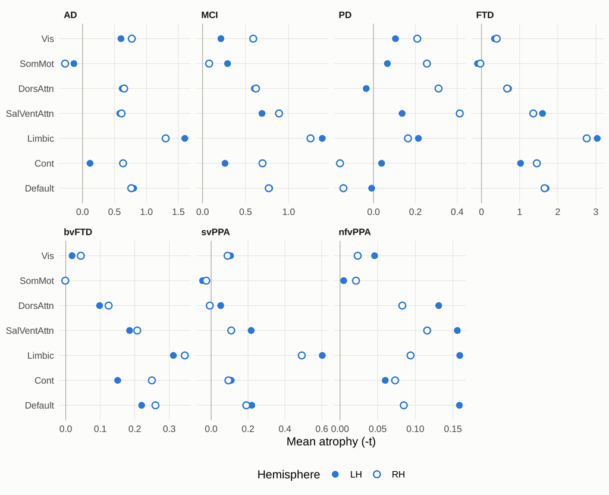

Mean atrophy (−t) by Schaefer network and hemisphere, Schaefer-400. Each panel has its own x-scale because the FTD-variant maps are on a much smaller scale (see Status).

```r
net_order <- c("Vis", "SomMot", "DorsAttn", "SalVentAttn", "Limbic", "Cont", "Default")
prof <- a400 %>% select(hemi, network, all_of(syn)) %>%
  pivot_longer(all_of(syn), names_to = "syndrome", values_to = "atrophy") %>%
  group_by(syndrome, hemi, network) %>% summarise(atrophy = mean(atrophy, na.rm = TRUE), .groups = "drop") %>%
  mutate(network = factor(network, rev(net_order)), syndrome = factor(syndrome, syn))
ggplot(prof, aes(atrophy, network, shape = hemi)) +
  geom_vline(xintercept = 0, colour = "#a8a79f", linewidth = 0.3) +
  geom_point(size = 2.4, colour = col_main, fill = "#fcfcfb", stroke = 0.9) +
  scale_shape_manual(values = c(LH = 16, RH = 21), name = "Hemisphere") +
  facet_wrap(~syndrome, scales = "free_x", ncol = 4) +
  labs(x = "Mean atrophy (-t)", y = NULL) + theme(legend.position = "bottom")
```

The svPPA map is most atrophic in the left, then right, limbic network (temporal pole). The nfvPPA map is left-lateralized; at network level it is flat across left limbic, default, salience and dorsal-attention parcels, and its peak parcels are left FEF/premotor, SMA and anterior insula/IFG (table above). The PD map is weak and diffuse. All three fit the clinical syndromes.

## 4.1 Scale of the FTD-variant maps

```r
rng <- do.call(rbind, lapply(syn, function(s) {
  img <- as.numeric(RNifti::readNifti(tmap_path(s))); v <- img[img != 0]
  data.frame(syndrome = s, voxel_t_min = round(min(v), 2), voxel_t_max = round(max(v), 2),
             parcel_atrophy_max = round(max(a400[[s]], na.rm = TRUE), 2),
             parcel_atrophy_sd = round(sd(a400[[s]], na.rm = TRUE), 3))
}))
rng
```

| syndrome | voxel_t_min | voxel_t_max | parcel_atrophy_max | parcel_atrophy_sd |
| --- | --- | --- | --- | --- |
| AD | -17.60 | 12.33 | 6.18 | 1.096 |
| MCI | -12.54 | 7.37 | 4.99 | 0.904 |
| PD | -7.51 | 3.89 | 2.51 | 0.580 |
| FTD | -16.43 | 13.77 | 8.29 | 1.293 |
| bvFTD | -1.46 | 1.55 | 0.92 | 0.168 |
| svPPA | -1.96 | 1.98 | 1.16 | 0.246 |
| nfvPPA | -1.52 | 1.58 | 0.67 | 0.161 |

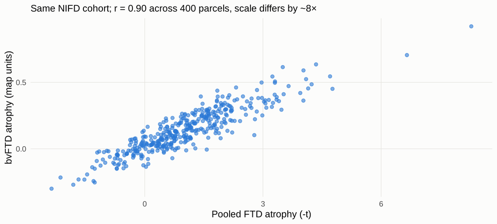

```r
ggplot(a400, aes(FTD, bvFTD)) +
  geom_point(colour = col_main, alpha = 0.6, size = 1.6) +
  labs(x = "Pooled FTD atrophy (-t)", y = "bvFTD atrophy (map units)",
       subtitle = sprintf("Same NIFD cohort; r = %.2f across 400 parcels, scale differs by ~%.0f×",
                          cor(a400$FTD, a400$bvFTD), sd(a400$FTD) / sd(a400$bvFTD)))
```

The bvFTD map has the same spatial pattern as the pooled FTD map (r = 0.90), but values about 8 times smaller in parcel-level SD (about 10 times in voxel range). One possible reading is that the variant maps are standardized effect sizes or t-values divided by a constant, rather than t-statistics; that is a guess and should be checked with the authors. It does not affect any planned analysis, because all of them use correlations, ranks or weighted averages.

# 5 Step 2: methods

```r
source("R/setup.R"); source("R/analysis.R"); source("R/results.R")
source("R/extensions.R")
res_k <- setNames(resolutions, resolutions)
D <- lapply(res_k, prep_resolution)
CC <- lapply(res_k, load_caches)
d4 <- D[["400"]]; c4 <- CC[["400"]]
syn <- colnames(d4$A)
primary <- c("AD", "bvFTD", "svPPA", "nfvPPA")
syn_lab <- function(x) factor(x, levels = syn)
fmt_p <- function(p) ifelse(is.na(p), "", ifelse(p < 0.001, "<0.001", sprintf("%.3f", p)))
```

**Inputs.** Atrophy a_i = −mean t per parcel (see “Parcellation and coverage”), seven maps. HCP SC with its 1/8/14 negative edges (100/200/400 parcels) set to 0; FC used as given (all entries ≥ 0). Euclidean distances between CBIG parcel centroids (MNI mm). Schaefer-400 is primary; 100 and 200 repeat everything.

**connectomeR.** The package tarball was not available. Following your instruction to go on, every function the analysis needs was written and validated before use (see “Validation of the new functions”). The network functions form a small R package, `pkg/netcomm` (communication models with C++ kernels, spin permutations, rewiring, variogram and Moran surrogates; roxygen documentation; 42 testthat expectations). `R CMD check --no-manual` on it returns **Status: OK (0 errors, 0 warnings, 0 notes)**; the PDF manual was skipped because the container has no LaTeX. The files are written to be merged into connectomeR as `R/communication.R` for version 0.3.0. That merge, the version bump and the check of connectomeR itself need the 0.2.0 source.

**Prediction rule.** For a model matrix M, P_i = Σ_{j≠i} M_ij a_j / Σ_{j≠i} M_ij and the statistic is r(a, P). With M = SC (or FC) this is the neighbour atrophy N_i of Zeighami et al. (2015) and Shafiei et al. (2023).

**Models on the SC.** Shortest-path efficiency (1/weighted path length, lengths 1/w); weighted communicability expm(S^-1/2 W S^-1/2) (Crofts & Higham 2009); search information (Goñi et al. 2014), used as the shortest-path probability 2^−SI; navigation efficiency with Euclidean greedy routing (Seguin et al. 2018); diffusion efficiency 1/MFPT (Goñi et al. 2013). Asymmetric measures were symmetrised as (M + Mᵀ)/2. Two models with one fitted parameter: the distance-only kernel exp(−d/λ) (λ over 40 values, 2–200 mm), and, added here, the network diffusion (heat) kernel expm(−βL) of Raj et al. (2012), with L the normalised Laplacian of the SC (β over 25 values). Fitted parameters were chosen to maximise r and **refitted inside every null surrogate and every rewired network**, so the nulls account for the fitting.

**Nulls (1,000 each).** (1) Spin: Hungarian-reassigned rotations of fsaverage5 parcel centroids (Vasa/Markello method), atrophy permuted, all predictions recomputed. (2) Degree-preserving rewiring of the SC (Maslov–Sneppen, 10 swaps per edge, weights travel with edges), all models recomputed on each rewired network, atrophy unchanged. Extensions add (3) geometry-preserving rewiring, (4) variogram-matched surrogates and (5) Moran spectral randomisation. p-values are one-sided (null r ≥ observed r) for model fits and two-sided for paired differences. FDR (Benjamini–Hochberg) is applied across syndromes × models within each null.

## 5.1 Validation of the new functions

```r
val <- read.csv("output/validation/communication_validation.csv")
val[, c("quantity", "reference", "max_abs_diff", "max_rel_diff", "offdiag_nonfinite_pattern_identical")]
```

| quantity | reference | max_abs_diff | max_rel_diff | offdiag_nonfinite_pattern_identical |
| --- | --- | --- | --- | --- |
| shortest-path length (L = 1/W) | bct.distance_wei | 0 | 0 | TRUE |
| weighted communicability | netneurotools.metrics.communicability_wei | 0 | 0 | TRUE |
| search information (bits) | bct.search_information(transform=‘inv’) | 0 | 0 | TRUE |
| navigation path length (sum 1/w) | bct.navigation_wu | 0 | 0 | TRUE |
| navigation hops | bct.navigation_wu | 0 | 0 | TRUE |
| mean first passage time | bct.mean_first_passage_time | 0 | 0 | TRUE |
| diffusion efficiency (1/MFPT) | bct.diffusion_efficiency | 0 | 0 | TRUE |

```r
spv <- read.csv("output/validation/spin_validation.csv")
data.frame(check = c("spin p-values, R vs neuromaps (21 map pairs): max |difference|",
                     "spin p-values: correlation", "null SD ratio R / neuromaps (range)",
                     "KS test of null distributions: min p"),
           value = c(sprintf("%.3f", max(abs(spv$p_spin_R - spv$p_spin_neuromaps))),
                     sprintf("%.4f", cor(spv$p_spin_R, spv$p_spin_neuromaps)),
                     sprintf("%.2f-%.2f", min(spv$null_sd_R / spv$null_sd_neuromaps), max(spv$null_sd_R / spv$null_sd_neuromaps)),
                     sprintf("%.2f", min(spv$ks_p_null))))
```

| check | value |
| --- | --- |
| spin p-values, R vs neuromaps (21 map pairs): max \|difference\| | 0.032 |
| spin p-values: correlation | 0.9993 |
| null SD ratio R / neuromaps (range) | 0.94-1.05 |
| KS test of null distributions: min p | 0.29 |

```r
rw <- read.csv("output/validation/rewiring_validation.csv")
aggregate(cbind(edge_turnover, mean_edge_length, ks_D_edge_length, weight_length_rho, interhemispheric_edges) ~ null, rw, function(v) round(mean(v), 3))
```

| null | edge_turnover | mean_edge_length | ks_D_edge_length | weight_length_rho | interhemispheric_edges |
| --- | --- | --- | --- | --- | --- |
| degree (Maslov-Sneppen), iter 10 | 0.923 | 79.643 | 0.595 | 0.011 | 2515.2 |
| degree + geometry (10 bins), iter 2000 | 0.540 | 38.252 | 0.028 | -0.543 | 1149.6 |
| degree + geometry, iter 2000 | 0.487 | 37.349 | 0.015 | -0.545 | 1116.0 |
| empirical | 0.000 | 36.742 | 0.000 | -0.545 | 964.0 |

Every communication model matches bctpy 0.6.1 or netneurotools 0.3.0 on the Schaefer-400 SC to floating-point precision. Two notes: bctpy’s `search_information` fails under NumPy 2, so the reference keeps bctpy’s own Floyd–Warshall and path retrieval and only flattens the returned path; navigation agrees exactly, including which pairs fail (94.0% of pairs succeed at 400 parcels). Spins match neuromaps’ Hungarian implementation in distribution. Degree-preserving rewiring moves 92% of edges and doubles the mean edge length; geometry-preserving rewiring keeps edge lengths and the weight–length relation but saturates at about 50% turnover.

# 6 A. Similarity between syndromes

```r
simA <- analysis_similarity(d4, c4$perms)
sur_v <- readRDS("output/cache/surrogates_variogram_k400.rds"); names(sur_v) <- syn
sur_m <- readRDS("output/cache/surrogates_moran_k400.rds"); names(sur_m) <- syn
simA$p_variogram <- mapply(function(a, b) p_two(cor(d4$A[, a], d4$A[, b]), colcor(sur_v[[a]], matrix(d4$A[, b], 400, ncol(sur_v[[a]])))), simA$map1, simA$map2)
simA$p_moran <- mapply(function(a, b) p_two(cor(d4$A[, a], d4$A[, b]), colcor(sur_m[[a]], matrix(d4$A[, b], 400, ncol(sur_m[[a]])))), simA$map1, simA$map2)
simA$q_variogram <- p.adjust(simA$p_variogram, "BH")
simA %>% mutate(across(where(is.numeric), ~ round(.x, 3)))
```

| map1 | map2 | r | p_spin | p_fdr | p_variogram | p_moran | q_variogram |
| --- | --- | --- | --- | --- | --- | --- | --- |
| AD | MCI | 0.799 | 0.001 | 0.002 | 0.001 | 0.001 | 0.003 |
| AD | PD | 0.102 | 0.209 | 0.274 | 0.239 | 0.259 | 0.313 |
| AD | FTD | 0.451 | 0.001 | 0.002 | 0.001 | 0.001 | 0.003 |
| AD | bvFTD | 0.314 | 0.018 | 0.027 | 0.027 | 0.005 | 0.038 |
| AD | svPPA | 0.480 | 0.001 | 0.002 | 0.003 | 0.001 | 0.007 |
| AD | nfvPPA | 0.217 | 0.014 | 0.023 | 0.013 | 0.008 | 0.023 |
| MCI | PD | 0.088 | 0.275 | 0.321 | 0.293 | 0.235 | 0.362 |
| MCI | FTD | 0.438 | 0.001 | 0.002 | 0.001 | 0.001 | 0.003 |
| MCI | bvFTD | 0.354 | 0.001 | 0.002 | 0.006 | 0.001 | 0.013 |
| MCI | svPPA | 0.405 | 0.002 | 0.003 | 0.016 | 0.001 | 0.024 |
| MCI | nfvPPA | 0.208 | 0.002 | 0.003 | 0.015 | 0.004 | 0.024 |
| PD | FTD | -0.037 | 0.592 | 0.655 | 0.789 | 0.624 | 0.872 |
| PD | bvFTD | -0.085 | 0.240 | 0.296 | 0.524 | 0.327 | 0.612 |
| PD | svPPA | -0.014 | 0.817 | 0.858 | 0.918 | 0.857 | 0.918 |
| PD | nfvPPA | -0.011 | 0.862 | 0.862 | 0.908 | 0.871 | 0.918 |
| FTD | bvFTD | 0.904 | 0.001 | 0.002 | 0.001 | 0.001 | 0.003 |
| FTD | svPPA | 0.770 | 0.001 | 0.002 | 0.001 | 0.001 | 0.003 |
| FTD | nfvPPA | 0.604 | 0.001 | 0.002 | 0.001 | 0.001 | 0.003 |
| bvFTD | svPPA | 0.499 | 0.001 | 0.002 | 0.001 | 0.001 | 0.003 |
| bvFTD | nfvPPA | 0.532 | 0.001 | 0.002 | 0.001 | 0.001 | 0.003 |
| svPPA | nfvPPA | 0.232 | 0.023 | 0.032 | 0.007 | 0.006 | 0.013 |

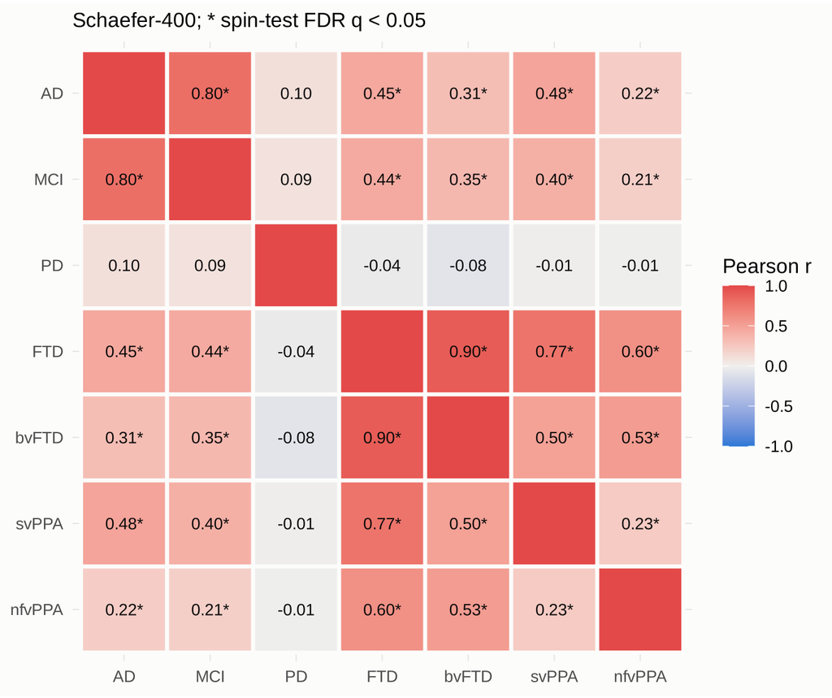

```r
Rm <- cor(d4$A)
Rl <- as.data.frame(as.table(Rm)) %>% setNames(c("a", "b", "r")) %>%
  left_join(bind_rows(simA %>% select(a = map1, b = map2, q = p_fdr), simA %>% select(a = map2, b = map1, q = p_fdr)), by = c("a", "b")) %>%
  mutate(lab = ifelse(a == b, "", paste0(sprintf("%.2f", r), ifelse(!is.na(q) & q < 0.05, "*", ""))),
         a = factor(a, syn), b = factor(b, rev(syn)))
ggplot(Rl, aes(a, b, fill = r)) +
  geom_tile(colour = "#fcfcfb", linewidth = 1) +
  geom_text(aes(label = lab), size = 3.1, colour = "#0b0b0b") +
  scale_fill_gradient2(low = pal_div[["low"]], mid = pal_div[["mid"]], high = pal_div[["high"]], midpoint = 0, limits = c(-1, 1), name = "Pearson r") +
  labs(x = NULL, y = NULL, subtitle = "Schaefer-400; * spin-test FDR q < 0.05") +
  coord_equal() + theme(panel.grid = element_blank())
```

# 7 B. Hub susceptibility

```r
hubB <- analysis_hubs(d4, c4$perms)
hubB %>% mutate(across(where(is.numeric), ~ round(.x, 3))) %>% arrange(matrix, syndrome)
```

| matrix | syndrome | rho | p_spin | p_fdr |
| --- | --- | --- | --- | --- |
| FC | AD | -0.148 | 0.412 | 0.576 |
| FC | FTD | -0.636 | 0.001 | 0.007 |
| FC | MCI | -0.254 | 0.023 | 0.064 |
| FC | PD | -0.001 | 0.993 | 0.993 |
| FC | bvFTD | -0.615 | 0.001 | 0.007 |
| FC | nfvPPA | -0.250 | 0.014 | 0.064 |
| FC | svPPA | -0.457 | 0.020 | 0.064 |
| SC | AD | -0.019 | 0.895 | 0.993 |
| SC | FTD | 0.224 | 0.198 | 0.336 |
| SC | MCI | 0.115 | 0.216 | 0.336 |
| SC | PD | 0.001 | 0.991 | 0.993 |
| SC | bvFTD | 0.267 | 0.030 | 0.070 |
| SC | nfvPPA | 0.168 | 0.054 | 0.108 |
| SC | svPPA | 0.043 | 0.873 | 0.993 |

Spearman correlation between node strength and atrophy; spin p, FDR across 2 matrices × 7 syndromes.

# 8 C. Network-constrained atrophy: SC vs FC

```r
mt4 <- model_table(c4)
C_tab <- mt4 %>% filter(R == 0, model %in% c("SC_direct", "FC")) %>%
  mutate(q_spin = p.adjust(p_spin, "BH"), q_variogram = p.adjust(p_variogram, "BH")) %>%
  group_by(model) %>% mutate(q_rew_deg = p.adjust(p_rew_deg, "BH"), q_rew_geo = p.adjust(p_rew_geo, "BH")) %>% ungroup() %>%
  select(syndrome, model, r, p_spin, q_spin, p_variogram, q_variogram, p_moran, p_rew_deg, q_rew_deg, p_rew_geo, q_rew_geo)
dSF <- difference_table(c4, ref = "FC", models = "SC_direct") %>% filter(R == 0) %>%
  select(syndrome, r_SC = r, r_FC = r_ref, diff, p_spin, q_spin, p_variogram)
C_tab %>% mutate(syndrome = syn_lab(syndrome)) %>% arrange(syndrome, model) %>% mutate(across(where(is.numeric), ~ round(.x, 3)))
```

| syndrome | model | r | p_spin | q_spin | p_variogram | q_variogram | p_moran | p_rew_deg | q_rew_deg | p_rew_geo | q_rew_geo |
| --- | --- | --- | --- | --- | --- | --- | --- | --- | --- | --- | --- |
| AD | FC | 0.374 | 0.145 | 0.179 | 0.361 | 0.571 | 0.114 | NA | NA | NA | NA |
| AD | SC_direct | 0.671 | 0.002 | 0.007 | 0.380 | 0.571 | 0.002 | 0.001 | 0.001 | 0.636 | 1.000 |
| MCI | FC | 0.265 | 0.143 | 0.179 | 0.741 | 0.865 | 0.160 | NA | NA | NA | NA |
| MCI | SC_direct | 0.526 | 0.027 | 0.054 | 0.977 | 0.977 | 0.193 | 0.001 | 0.001 | 0.939 | 1.000 |
| PD | FC | 0.227 | 0.035 | 0.059 | 0.616 | 0.784 | 0.125 | NA | NA | NA | NA |
| PD | SC_direct | 0.431 | 0.003 | 0.008 | 0.906 | 0.976 | 0.285 | 0.001 | 0.001 | 0.305 | 0.821 |
| FTD | FC | 0.537 | 0.002 | 0.007 | 0.004 | 0.028 | 0.001 | NA | NA | NA | NA |
| FTD | SC_direct | 0.645 | 0.154 | 0.179 | 0.090 | 0.252 | 0.089 | 0.001 | 0.001 | 0.943 | 1.000 |
| bvFTD | FC | 0.582 | 0.001 | 0.007 | 0.001 | 0.014 | 0.001 | NA | NA | NA | NA |
| bvFTD | SC_direct | 0.665 | 0.001 | 0.007 | 0.058 | 0.252 | 0.002 | 0.001 | 0.001 | 0.074 | 0.517 |
| svPPA | FC | 0.489 | 0.350 | 0.377 | 0.077 | 0.252 | 0.315 | NA | NA | NA | NA |
| svPPA | SC_direct | 0.715 | 0.619 | 0.619 | 0.124 | 0.289 | 0.598 | 0.001 | 0.001 | 1.000 | 1.000 |
| nfvPPA | FC | 0.279 | 0.017 | 0.040 | 0.194 | 0.388 | 0.017 | NA | NA | NA | NA |
| nfvPPA | SC_direct | 0.448 | 0.038 | 0.059 | 0.408 | 0.571 | 0.049 | 0.001 | 0.001 | 0.352 | 0.821 |

```r
dSF %>% mutate(syndrome = syn_lab(syndrome)) %>% arrange(syndrome) %>% mutate(across(where(is.numeric), ~ round(.x, 3)))
```

| syndrome | r_SC | r_FC | diff | p_spin | q_spin | p_variogram |
| --- | --- | --- | --- | --- | --- | --- |
| AD | 0.671 | 0.374 | 0.297 | 0.338 | 0.998 | 0.579 |
| MCI | 0.526 | 0.265 | 0.261 | 0.443 | 0.998 | 0.698 |
| PD | 0.431 | 0.227 | 0.204 | 0.615 | 0.998 | 0.802 |
| FTD | 0.645 | 0.537 | 0.109 | 0.992 | 0.998 | 0.995 |
| bvFTD | 0.665 | 0.582 | 0.083 | 0.998 | 0.998 | 0.998 |
| svPPA | 0.715 | 0.489 | 0.226 | 0.699 | 0.998 | 0.838 |
| nfvPPA | 0.448 | 0.279 | 0.169 | 0.768 | 0.998 | 0.818 |

The rewiring nulls apply only to the SC (FC is a dense correlation matrix). FDR for the spatial nulls covers 7 syndromes × 2 matrices; for the rewiring nulls, the 7 syndromes.

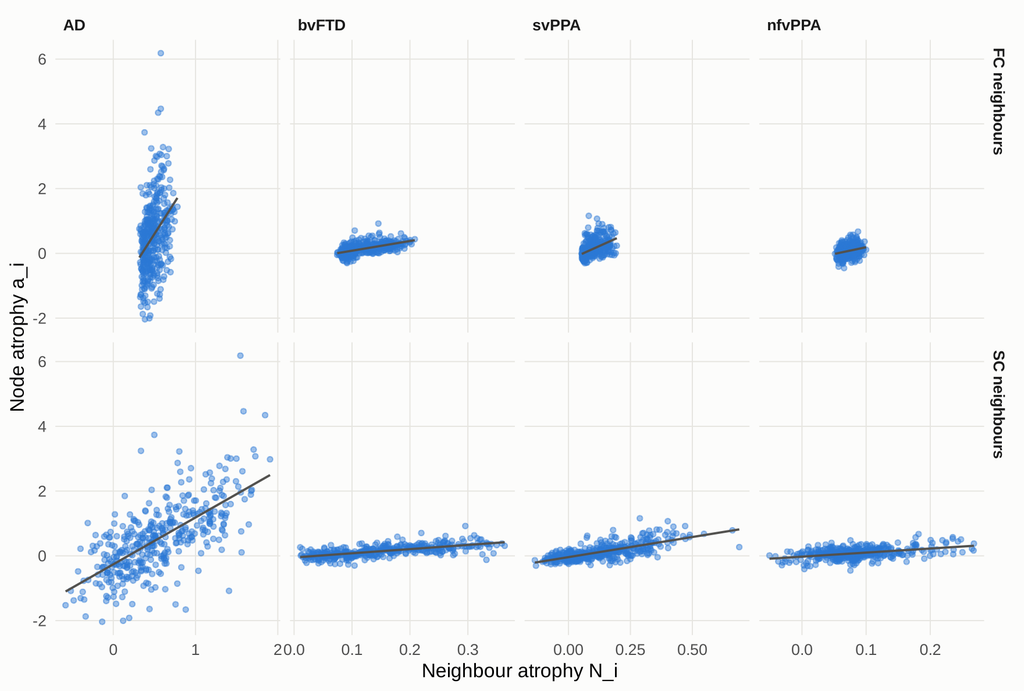

```r
nb <- do.call(rbind, lapply(primary, function(s) rbind(
  data.frame(syndrome = s, matrix = "SC neighbours", a = d4$A[, s], N = predict_from_model(d4$SC, d4$A[, s])),
  data.frame(syndrome = s, matrix = "FC neighbours", a = d4$A[, s], N = predict_from_model(d4$FC, d4$A[, s])))))
nb$syndrome <- factor(nb$syndrome, primary)
ggplot(nb, aes(N, a)) + geom_point(colour = col_main, alpha = 0.45, size = 1.1) +
  geom_smooth(method = "lm", se = FALSE, colour = "#52514e", linewidth = 0.6) +
  facet_grid(matrix ~ syndrome, scales = "free") +
  labs(x = "Neighbour atrophy N_i", y = "Node atrophy a_i")
```

# 9 D. Epicentres

```r
ep <- epicentre_table(d4, c4)
flipN <- c4$flipped
ep_flip <- do.call(rbind, lapply(syn, function(s) { a <- flipN[, s]; sc <- epicentre_score(a, predict_from_model(d4$SC, a)); data.frame(syndrome = s, parcel = seq_along(a), rank_mirrored = rank(-sc, ties.method = "min")) }))
ep_fc <- epicentre_table(d4, list(perms = c4$perms), W = d4$FC) %>% select(syndrome, parcel, rank_FC = rank)
ep <- ep %>% left_join(ep_flip, by = c("syndrome", "parcel")) %>% left_join(ep_fc, by = c("syndrome", "parcel"))
top_ep <- ep %>% filter(rank <= 10) %>% arrange(syndrome_order = match(syndrome, syn), rank) %>%
  transmute(syndrome, rank, parcel = short_label(label), atrophy = round(atrophy, 3), neighbour = round(neighbour, 3),
            p_spin = fmt_p(p_spin), p_rewire = fmt_p(p_rew_deg), rank_FC, rank_mirrored)
top_ep %>% filter(syndrome %in% primary)
```

| syndrome | rank | parcel | atrophy | neighbour | p_spin | p_rewire | rank_FC | rank_mirrored |
| --- | --- | --- | --- | --- | --- | --- | --- | --- |
| AD | 1 | LH_Limbic_TempPole_3 | 4.345 | 1.846 | 0.004 | 0.003 | 35 | 1 |
| AD | 2 | LH_Limbic_TempPole_5 | 3.282 | 1.706 | 0.005 | 0.010 | 8 | 8 |
| AD | 3 | LH_Limbic_TempPole_7 | 3.074 | 1.727 | 0.007 | 0.015 | 27 | 12 |
| AD | 4 | LH_Limbic_TempPole_8 | 4.465 | 1.583 | 0.007 | 0.048 | 15 | 2 |
| AD | 5 | LH_Limbic_TempPole_2 | 2.980 | 1.906 | 0.006 | 0.002 | 43 | 6 |
| AD | 6 | RH_Limbic_TempPole_7 | 6.183 | 1.545 | 0.004 | 0.032 | 15 | 4 |
| AD | 7 | RH_Cont_Temp_1 | 2.612 | 1.570 | 0.020 | 0.046 | 10 | 52 |
| AD | 7 | RH_Default_Temp_7 | 3.002 | 1.497 | 0.026 | 0.079 | 4 | 21 |
| AD | 9 | RH_Vis_7 | 3.006 | 1.427 | 0.012 | 0.044 | 53 | 18 |
| AD | 10 | RH_Vis_2 | 3.042 | 1.388 | 0.004 | 0.014 | 19 | 17 |
| bvFTD | 1 | RH_Limbic_OFC_1 | 0.507 | 0.323 | 0.006 | 0.011 | 55 | 5 |
| bvFTD | 2 | RH_Cont_PFCv_1 | 0.635 | 0.311 | 0.008 | 0.038 | 31 | 6 |
| bvFTD | 3 | LH_SalVentAttn_FrOperIns_3 | 0.545 | 0.316 | 0.011 | 0.040 | 56 | 3 |
| bvFTD | 4 | LH_Default_PFC_18 | 0.499 | 0.321 | 0.014 | 0.028 | 3 | 8 |
| bvFTD | 5 | LH_Cont_PFCv_1 | 0.921 | 0.296 | 0.021 | 0.060 | 37 | 2 |
| bvFTD | 6 | LH_Limbic_OFC_2 | 0.544 | 0.305 | 0.010 | 0.020 | 48 | 14 |
| bvFTD | 6 | RH_Limbic_OFC_5 | 0.407 | 0.332 | 0.026 | 0.021 | 50 | 27 |
| bvFTD | 8 | LH_Default_PFC_1 | 0.382 | 0.359 | 0.025 | 0.002 | 26 | 34 |
| bvFTD | 9 | LH_Limbic_OFC_1 | 0.524 | 0.291 | 0.022 | 0.029 | 10 | 7 |
| bvFTD | 9 | RH_Limbic_OFC_2 | 0.385 | 0.325 | 0.026 | 0.008 | 74 | 4 |
| svPPA | 1 | LH_Limbic_TempPole_2 | 0.920 | 0.471 | 0.011 | 0.028 | 24 | 2 |
| svPPA | 1 | LH_Limbic_TempPole_7 | 0.787 | 0.662 | 0.030 | 0.021 | 10 | 1 |
| svPPA | 3 | LH_Limbic_TempPole_5 | 0.901 | 0.423 | 0.036 | 0.029 | 11 | 21 |
| svPPA | 4 | LH_Limbic_TempPole_4 | 0.680 | 0.547 | 0.038 | 0.009 | 14 | 22 |
| svPPA | 5 | LH_Cont_PFCv_1 | 1.070 | 0.401 | 0.047 | 0.031 | 32 | 31 |
| svPPA | 6 | RH_Limbic_TempPole_5 | 0.649 | 0.490 | 0.018 | 0.026 | 16 | 9 |
| svPPA | 7 | LH_Limbic_TempPole_3 | 0.693 | 0.436 | 0.047 | 0.033 | 26 | 27 |
| svPPA | 7 | LH_Default_Temp_1 | 0.712 | 0.422 | 0.030 | 0.028 | 3 | 35 |
| svPPA | 9 | LH_Limbic_OFC_4 | 0.805 | 0.368 | 0.049 | 0.057 | 6 | 24 |
| svPPA | 10 | LH_Limbic_TempPole_6 | 0.732 | 0.399 | 0.031 | 0.017 | 2 | 35 |
| nfvPPA | 1 | LH_SalVentAttn_FrOperIns_3 | 0.507 | 0.248 | 0.011 | 0.006 | 10 | 9 |
| nfvPPA | 2 | LH_DorsAttn_FEF_4 | 0.576 | 0.235 | 0.009 | 0.012 | 27 | 14 |
| nfvPPA | 3 | LH_DorsAttn_FEF_2 | 0.529 | 0.235 | 0.007 | 0.010 | 53 | 38 |
| nfvPPA | 4 | RH_SalVentAttn_Med_8 | 0.443 | 0.243 | <0.001 | 0.005 | 16 | 3 |
| nfvPPA | 5 | LH_DorsAttn_FEF_3 | 0.378 | 0.268 | 0.022 | 0.003 | 71 | 25 |
| nfvPPA | 6 | LH_SalVentAttn_FrOperIns_5 | 0.481 | 0.219 | 0.018 | 0.027 | 12 | 20 |
| nfvPPA | 6 | LH_Default_PFC_7 | 0.420 | 0.225 | 0.013 | 0.045 | 9 | 40 |
| nfvPPA | 8 | LH_DorsAttn_FEF_1 | 0.487 | 0.201 | 0.020 | 0.037 | 86 | 131 |
| nfvPPA | 8 | LH_SalVentAttn_FrOperIns_6 | 0.382 | 0.224 | 0.021 | 0.027 | 44 | 30 |
| nfvPPA | 10 | LH_Cont_PFCv_1 | 0.673 | 0.182 | 0.035 | 0.053 | 3 | 34 |

`rank_mirrored` is the parcel’s epicentre rank when the voxel map is mirrored left–right before parcellation (so a left parcel then samples right-hemisphere data). An epicentre that keeps its rank under mirroring is not specific to its hemisphere; see “Laterality and the atlas”.

```r
ins <- ep %>% filter(syndrome == "bvFTD", grepl("FrOperIns|PFCv|Ins", label)) %>% arrange(rank) %>%
  transmute(parcel = short_label(label), rank, p_spin = fmt_p(p_spin), p_rewire = fmt_p(p_rew_deg), rank_mirrored) %>% head(8)
ins
```

| parcel | rank | p_spin | p_rewire | rank_mirrored |
| --- | --- | --- | --- | --- |
| RH_Cont_PFCv_1 | 2 | 0.008 | 0.038 | 6 |
| LH_SalVentAttn_FrOperIns_3 | 3 | 0.011 | 0.040 | 3 |
| LH_Cont_PFCv_1 | 5 | 0.021 | 0.060 | 2 |
| RH_Default_PFCv_2 | 12 | 0.051 | 0.017 | 41 |
| RH_Default_PFCv_1 | 16 | 0.065 | 0.003 | 1 |
| LH_SalVentAttn_FrOperIns_5 | 20 | 0.023 | 0.122 | 30 |
| RH_SalVentAttn_FrOperIns_2 | 24 | 0.061 | 0.112 | 16 |
| RH_SalVentAttn_FrOperIns_1 | 27 | 0.125 | 0.036 | 25 |

# 10 E. Communication models on the SC

```r
E_models <- c("SC_direct", "SPE", "communicability", "search_prob", "navigation", "diffusion", "heat", "distance")
E_tab <- mt4 %>% filter(R == 0, model %in% E_models) %>%
  mutate(syndrome = syn_lab(syndrome), model = factor(model, E_models)) %>% arrange(syndrome, model)
E_tab %>% select(syndrome, model, r, param, p_spin, q_spin, p_rew_deg, q_rew_deg, p_rew_geo) %>%
  mutate(param = ifelse(model %in% c("distance", "heat"), signif(param, 3), NA)) %>%
  mutate(across(c(r, p_spin, q_spin, p_rew_deg, q_rew_deg, p_rew_geo), ~ round(.x, 3)))
```

| syndrome | model | r | param | p_spin | q_spin | p_rew_deg | q_rew_deg | p_rew_geo |
| --- | --- | --- | --- | --- | --- | --- | --- | --- |
| AD | SC_direct | 0.671 | NA | 0.002 | 0.007 | 0.001 | 0.001 | 0.636 |
| AD | SPE | 0.549 | NA | 0.018 | 0.042 | 0.001 | 0.001 | 0.263 |
| AD | communicability | 0.644 | NA | 0.003 | 0.008 | 0.001 | 0.001 | 0.840 |
| AD | search_prob | 0.670 | NA | 0.002 | 0.007 | 0.001 | 0.001 | 0.490 |
| AD | navigation | 0.524 | NA | 0.113 | 0.162 | 0.001 | 0.001 | 0.799 |
| AD | diffusion | 0.154 | NA | 0.112 | 0.162 | 0.001 | 0.001 | 0.001 |
| AD | heat | 0.674 | 0.10 | 0.002 | 0.007 | 0.001 | 0.001 | 0.678 |
| AD | distance | 0.758 | 3.61 | 0.001 | 0.007 | NA | NA | NA |
| MCI | SC_direct | 0.526 | NA | 0.027 | 0.056 | 0.001 | 0.001 | 0.939 |
| MCI | SPE | 0.420 | NA | 0.033 | 0.066 | 0.001 | 0.001 | 0.767 |
| MCI | communicability | 0.501 | NA | 0.040 | 0.075 | 0.001 | 0.001 | 0.993 |
| MCI | search_prob | 0.526 | NA | 0.025 | 0.054 | 0.001 | 0.001 | 0.934 |
| MCI | navigation | 0.407 | NA | 0.091 | 0.150 | 0.001 | 0.001 | 0.918 |
| MCI | diffusion | -0.362 | NA | 0.815 | 0.830 | 0.001 | 0.001 | 0.001 |
| MCI | heat | 0.531 | 0.10 | 0.023 | 0.051 | 0.001 | 0.001 | 0.948 |
| MCI | distance | 0.680 | 4.06 | 0.001 | 0.007 | NA | NA | NA |
| PD | SC_direct | 0.431 | NA | 0.003 | 0.008 | 0.001 | 0.001 | 0.305 |
| PD | SPE | 0.332 | NA | 0.008 | 0.019 | 0.001 | 0.001 | 0.171 |
| PD | communicability | 0.421 | NA | 0.003 | 0.008 | 0.001 | 0.001 | 0.356 |
| PD | search_prob | 0.437 | NA | 0.002 | 0.007 | 0.001 | 0.001 | 0.213 |
| PD | navigation | 0.364 | NA | 0.002 | 0.007 | 0.001 | 0.001 | 0.109 |
| PD | diffusion | -0.352 | NA | 0.202 | 0.251 | 0.001 | 0.001 | 0.001 |
| PD | heat | 0.435 | 0.10 | 0.002 | 0.007 | 0.001 | 0.001 | 0.284 |
| PD | distance | 0.598 | 3.61 | 0.001 | 0.007 | NA | NA | NA |
| FTD | SC_direct | 0.645 | NA | 0.154 | 0.200 | 0.001 | 0.001 | 0.943 |
| FTD | SPE | 0.578 | NA | 0.097 | 0.151 | 0.001 | 0.001 | 0.544 |
| FTD | communicability | 0.631 | NA | 0.153 | 0.200 | 0.001 | 0.001 | 0.982 |
| FTD | search_prob | 0.644 | NA | 0.147 | 0.200 | 0.001 | 0.001 | 0.872 |
| FTD | navigation | 0.580 | NA | 0.109 | 0.162 | 0.001 | 0.001 | 0.648 |
| FTD | diffusion | -0.102 | NA | 0.952 | 0.952 | 0.001 | 0.001 | 0.001 |
| FTD | heat | 0.649 | 0.10 | 0.138 | 0.193 | 0.001 | 0.001 | 0.954 |
| FTD | distance | 0.738 | 3.61 | 0.005 | 0.013 | NA | NA | NA |
| bvFTD | SC_direct | 0.665 | NA | 0.001 | 0.007 | 0.001 | 0.001 | 0.074 |
| bvFTD | SPE | 0.596 | NA | 0.001 | 0.007 | 0.001 | 0.001 | 0.001 |
| bvFTD | communicability | 0.649 | NA | 0.002 | 0.007 | 0.001 | 0.001 | 0.074 |
| bvFTD | search_prob | 0.664 | NA | 0.003 | 0.008 | 0.001 | 0.001 | 0.038 |
| bvFTD | navigation | 0.593 | NA | 0.002 | 0.007 | 0.001 | 0.001 | 0.007 |
| bvFTD | diffusion | -0.078 | NA | 0.791 | 0.821 | 0.001 | 0.001 | 0.001 |
| bvFTD | heat | 0.667 | 0.10 | 0.002 | 0.007 | 0.001 | 0.001 | 0.094 |
| bvFTD | distance | 0.720 | 3.61 | 0.004 | 0.011 | NA | NA | NA |
| svPPA | SC_direct | 0.715 | NA | 0.619 | 0.708 | 0.001 | 0.001 | 1.000 |
| svPPA | SPE | 0.641 | NA | 0.686 | 0.751 | 0.001 | 0.001 | 1.000 |
| svPPA | communicability | 0.703 | NA | 0.668 | 0.749 | 0.001 | 0.001 | 1.000 |
| svPPA | search_prob | 0.718 | NA | 0.545 | 0.650 | 0.001 | 0.001 | 1.000 |
| svPPA | navigation | 0.643 | NA | 0.697 | 0.751 | 0.001 | 0.001 | 1.000 |
| svPPA | diffusion | 0.357 | NA | 0.497 | 0.604 | 0.001 | 0.001 | 0.001 |
| svPPA | heat | 0.721 | 0.10 | 0.573 | 0.669 | 0.001 | 0.001 | 1.000 |
| svPPA | distance | 0.827 | 3.61 | 0.003 | 0.008 | NA | NA | NA |
| nfvPPA | SC_direct | 0.448 | NA | 0.038 | 0.073 | 0.001 | 0.001 | 0.352 |
| nfvPPA | SPE | 0.324 | NA | 0.161 | 0.205 | 0.001 | 0.001 | 0.414 |
| nfvPPA | communicability | 0.428 | NA | 0.061 | 0.107 | 0.001 | 0.001 | 0.317 |
| nfvPPA | search_prob | 0.436 | NA | 0.083 | 0.141 | 0.001 | 0.001 | 0.433 |
| nfvPPA | navigation | 0.349 | NA | 0.097 | 0.151 | 0.001 | 0.001 | 0.306 |
| nfvPPA | diffusion | -0.346 | NA | 0.728 | 0.769 | 0.001 | 0.001 | 0.001 |
| nfvPPA | heat | 0.447 | 0.10 | 0.050 | 0.090 | 0.001 | 0.001 | 0.370 |
| nfvPPA | distance | 0.570 | 4.06 | 0.001 | 0.007 | NA | NA | NA |

`param` is the fitted λ (mm) for the distance kernel and β for the heat kernel. FDR covers the 8 SC/distance models (SC direct, SPE, communicability, search information, navigation, diffusion, heat kernel, distance) × 7 syndromes, separately for each null.

Reading the p-values: they are one-sided (is the observed r larger than the null r?). Diffusion efficiency gives **negative** r, yet small rewiring p-values, because rewired networks give even more negative r. That is not evidence of a network constraint. On large graphs, 1/MFPT is dominated by the target node’s stationary probability, i.e. its strength (von Luxburg et al. 2014, JMLR 15:1751), so the “prediction” collapses to a function of node strength:

```r
P_diff <- predict_from_model(communication_models(d4$SC, d4$Dist)$diffusion, d4$A)
round(sapply(syn, function(s) cor(P_diff[, s], rowSums(d4$SC))), 2)
```

```
##     AD    MCI     PD    FTD  bvFTD  svPPA nfvPPA
##  -0.10  -0.56  -0.22  -0.70  -0.67  -0.27  -0.64
```

The heat kernel’s fitted β is at or near the lowest grid value for most syndromes; as β → 0 the kernel converges to one-step, degree-normalised SC, so the best-fitting “diffusion” is no diffusion beyond direct neighbours.

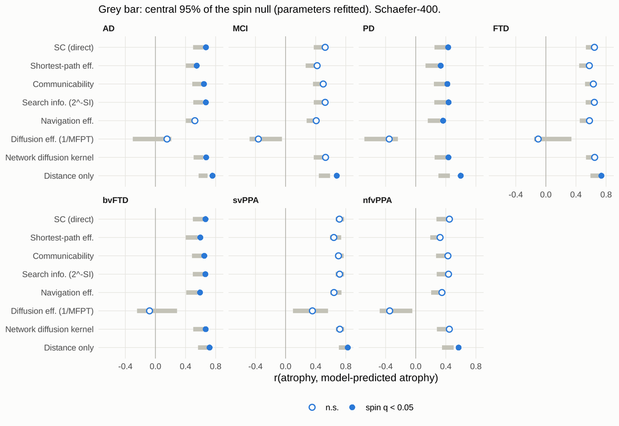

```r
spin_band <- c4$spin %>% filter(R == 0, model %in% E_models) %>% group_by(model, syndrome) %>%
  summarise(lo = quantile(r, 0.025, na.rm = TRUE), hi = quantile(r, 0.975, na.rm = TRUE), .groups = "drop")
pe <- E_tab %>% mutate(model = as.character(model), syndrome = as.character(syndrome)) %>% left_join(spin_band, by = c("model", "syndrome")) %>%
  mutate(model = factor(model_labels[model], rev(model_labels[E_models])), syndrome = syn_lab(syndrome),
         sig = ifelse(q_spin < 0.05, "spin q < 0.05", "n.s."))
ggplot(pe, aes(r, model)) +
  geom_vline(xintercept = 0, colour = "#a8a79f", linewidth = 0.3) +
  geom_errorbarh(aes(xmin = lo, xmax = hi), height = 0, colour = "#c3c2b7", linewidth = 2.2) +
  geom_point(aes(shape = sig), colour = col_main, fill = "#fcfcfb", size = 2.3, stroke = 0.9) +
  scale_shape_manual(values = c("spin q < 0.05" = 16, "n.s." = 21), name = NULL) +
  facet_wrap(~syndrome, ncol = 4) +
  labs(x = "r(atrophy, model-predicted atrophy)", y = NULL, subtitle = "Grey bar: central 95% of the spin null (parameters refitted). Schaefer-400.") +
  theme(legend.position = "bottom")
```

**Does any model beat the distance-only baseline?** Paired difference r_model − r_distance; two-sided spin p of the difference (both refitted in each spin); FDR across 7 models × 7 syndromes.

```r
vsD <- difference_table(c4, ref = "distance", models = setdiff(E_models, "distance")) %>% filter(R == 0) %>%
  mutate(syndrome = syn_lab(syndrome), model = factor(model, E_models)) %>% arrange(syndrome, desc(diff))
vsD %>% select(syndrome, model, r, r_distance = r_ref, diff, p_spin, q_spin, p_variogram, q_variogram) %>%
  mutate(across(where(is.numeric), ~ round(.x, 3)))
```

| syndrome | model | r | r_distance | diff | p_spin | q_spin | p_variogram | q_variogram |
| --- | --- | --- | --- | --- | --- | --- | --- | --- |
| AD | heat | 0.674 | 0.758 | -0.085 | 0.226 | 0.283 | 0.329 | 0.393 |
| AD | SC_direct | 0.671 | 0.758 | -0.087 | 0.225 | 0.283 | 0.329 | 0.393 |
| AD | search_prob | 0.670 | 0.758 | -0.088 | 0.227 | 0.283 | 0.384 | 0.448 |
| AD | communicability | 0.644 | 0.758 | -0.114 | 0.131 | 0.183 | 0.193 | 0.274 |
| AD | SPE | 0.549 | 0.758 | -0.210 | 0.089 | 0.141 | 0.154 | 0.228 |
| AD | navigation | 0.524 | 0.758 | -0.234 | 0.023 | 0.061 | 0.087 | 0.175 |
| AD | diffusion | 0.154 | 0.758 | -0.604 | 0.553 | 0.611 | 0.237 | 0.313 |
| MCI | heat | 0.531 | 0.680 | -0.149 | 0.026 | 0.061 | 0.011 | 0.035 |
| MCI | SC_direct | 0.526 | 0.680 | -0.154 | 0.022 | 0.061 | 0.012 | 0.035 |
| MCI | search_prob | 0.526 | 0.680 | -0.154 | 0.024 | 0.061 | 0.013 | 0.035 |
| MCI | communicability | 0.501 | 0.680 | -0.179 | 0.011 | 0.045 | 0.009 | 0.034 |
| MCI | SPE | 0.420 | 0.680 | -0.261 | 0.028 | 0.062 | 0.015 | 0.039 |
| MCI | navigation | 0.407 | 0.680 | -0.273 | 0.011 | 0.045 | 0.009 | 0.034 |
| MCI | diffusion | -0.362 | 0.680 | -1.042 | 0.010 | 0.045 | 0.002 | 0.016 |
| PD | search_prob | 0.437 | 0.598 | -0.161 | 0.013 | 0.049 | 0.001 | 0.012 |
| PD | heat | 0.435 | 0.598 | -0.163 | 0.008 | 0.045 | 0.001 | 0.012 |
| PD | SC_direct | 0.431 | 0.598 | -0.167 | 0.007 | 0.045 | 0.002 | 0.016 |
| PD | communicability | 0.421 | 0.598 | -0.177 | 0.006 | 0.045 | 0.001 | 0.012 |
| PD | navigation | 0.364 | 0.598 | -0.234 | 0.030 | 0.064 | 0.006 | 0.027 |
| PD | SPE | 0.332 | 0.598 | -0.266 | 0.016 | 0.052 | 0.001 | 0.012 |
| PD | diffusion | -0.352 | 0.598 | -0.950 | 0.214 | 0.283 | 0.004 | 0.022 |
| FTD | heat | 0.649 | 0.738 | -0.089 | 0.099 | 0.144 | 0.142 | 0.220 |
| FTD | SC_direct | 0.645 | 0.738 | -0.092 | 0.100 | 0.144 | 0.142 | 0.220 |
| FTD | search_prob | 0.644 | 0.738 | -0.094 | 0.096 | 0.144 | 0.144 | 0.220 |
| FTD | communicability | 0.631 | 0.738 | -0.107 | 0.088 | 0.141 | 0.106 | 0.185 |
| FTD | navigation | 0.580 | 0.738 | -0.158 | 0.231 | 0.283 | 0.245 | 0.313 |
| FTD | SPE | 0.578 | 0.738 | -0.160 | 0.242 | 0.289 | 0.249 | 0.313 |
| FTD | diffusion | -0.102 | 0.738 | -0.840 | 0.017 | 0.052 | 0.018 | 0.042 |
| bvFTD | heat | 0.667 | 0.720 | -0.052 | 0.586 | 0.611 | 0.602 | 0.612 |
| bvFTD | SC_direct | 0.665 | 0.720 | -0.055 | 0.582 | 0.611 | 0.608 | 0.612 |
| bvFTD | search_prob | 0.664 | 0.720 | -0.056 | 0.585 | 0.611 | 0.609 | 0.612 |
| bvFTD | communicability | 0.649 | 0.720 | -0.071 | 0.548 | 0.611 | 0.453 | 0.504 |
| bvFTD | SPE | 0.596 | 0.720 | -0.124 | 0.770 | 0.770 | 0.612 | 0.612 |
| bvFTD | navigation | 0.593 | 0.720 | -0.127 | 0.703 | 0.718 | 0.538 | 0.586 |
| bvFTD | diffusion | -0.078 | 0.720 | -0.798 | 0.075 | 0.131 | 0.040 | 0.085 |
| svPPA | heat | 0.721 | 0.827 | -0.106 | 0.006 | 0.045 | 0.100 | 0.181 |
| svPPA | search_prob | 0.718 | 0.827 | -0.109 | 0.010 | 0.045 | 0.113 | 0.191 |
| svPPA | SC_direct | 0.715 | 0.827 | -0.111 | 0.005 | 0.045 | 0.093 | 0.175 |
| svPPA | communicability | 0.703 | 0.827 | -0.124 | 0.004 | 0.045 | 0.091 | 0.175 |
| svPPA | navigation | 0.643 | 0.827 | -0.184 | 0.011 | 0.045 | 0.217 | 0.295 |
| svPPA | SPE | 0.641 | 0.827 | -0.186 | 0.011 | 0.045 | 0.196 | 0.274 |
| svPPA | diffusion | 0.357 | 0.827 | -0.470 | 0.319 | 0.372 | 0.435 | 0.495 |
| nfvPPA | SC_direct | 0.448 | 0.570 | -0.122 | 0.081 | 0.137 | 0.023 | 0.051 |
| nfvPPA | heat | 0.447 | 0.570 | -0.123 | 0.074 | 0.131 | 0.012 | 0.035 |
| nfvPPA | search_prob | 0.436 | 0.570 | -0.134 | 0.051 | 0.100 | 0.011 | 0.035 |
| nfvPPA | communicability | 0.428 | 0.570 | -0.142 | 0.053 | 0.100 | 0.006 | 0.027 |
| nfvPPA | navigation | 0.349 | 0.570 | -0.221 | 0.039 | 0.080 | 0.004 | 0.022 |
| nfvPPA | SPE | 0.324 | 0.570 | -0.246 | 0.016 | 0.052 | 0.004 | 0.022 |
| nfvPPA | diffusion | -0.346 | 0.570 | -0.916 | 0.026 | 0.061 | 0.018 | 0.042 |

```r
best_by_syn <- E_tab %>% filter(model != "distance") %>% group_by(syndrome) %>% slice_max(r, n = 1) %>% select(syndrome, best_model = model, r)
best_by_syn
```

| syndrome | best_model | r |
| --- | --- | --- |
| AD | heat | 0.6735320 |
| MCI | heat | 0.5311143 |
| PD | search_prob | 0.4367602 |
| FTD | heat | 0.6486526 |
| bvFTD | heat | 0.6674941 |
| svPPA | heat | 0.7206728 |
| nfvPPA | SC_direct | 0.4477452 |

**What the distance baseline measures.** The fitted length scale is about 3.6 mm, so about 60% of each parcel’s prediction weight comes from parcels within 15 mm (the median nearest-parcel distance is 11 mm). The distance kernel therefore measures how *smooth* the map is (a parcel resembles its immediate neighbours), not whether disease spreads locally. The AD pattern itself is distributed: its 40 most atrophic parcels form 22 separate clusters (medial temporal, posterior cingulate/precuneus, lateral temporal, insula on both sides). Linking these distant clusters is what the network models should add, and that is tested directly in “Distance-censored prediction” (only parcels > R mm away may be used) and “Unique contribution beyond distance”.

```r
K36 <- comm_distance(d4$Dist, 3.6); same_h <- outer(d4$info$hemi, d4$info$hemi, "==")
Kw <- K36; Kw[!same_h] <- 0; Ka <- K36; Ka[same_h] <- 0
data.frame(syndrome = syn,
           r_distance_all = sapply(syn, function(s) cor(d4$A[, s], predict_from_model(K36, d4$A[, s]))),
           r_distance_same_hemisphere = sapply(syn, function(s) cor(d4$A[, s], predict_from_model(Kw, d4$A[, s]))),
           r_distance_other_hemisphere = sapply(syn, function(s) cor(d4$A[, s], predict_from_model(Ka, d4$A[, s]))),
           r_mirror_location = sapply(syn, function(s) cor(d4$A[, s], c4$flipped[, s]))) %>%
  mutate(across(where(is.numeric), ~ round(.x, 2)))
```

|  | syndrome | r_distance_all | r_distance_same_hemisphere | r_distance_other_hemisphere | r_mirror_location |
| --- | --- | --- | --- | --- | --- |
| AD | AD | 0.76 | 0.75 | 0.51 | 0.81 |
| MCI | MCI | 0.68 | 0.67 | 0.30 | 0.63 |
| PD | PD | 0.60 | 0.58 | 0.25 | 0.29 |
| FTD | FTD | 0.74 | 0.73 | 0.59 | 0.85 |
| bvFTD | bvFTD | 0.72 | 0.72 | 0.47 | 0.81 |
| svPPA | svPPA | 0.83 | 0.82 | 0.65 | 0.82 |
| nfvPPA | nfvPPA | 0.57 | 0.55 | 0.14 | 0.44 |

In AD, bvFTD and pooled FTD the single best predictor of a parcel’s atrophy is the atrophy at its **mirror location in the other hemisphere** (`r_mirror_location`; r = 0.81, 0.81, 0.85, above the distance kernel): these patterns are largely bilateral and symmetric, which neither a short-range kernel nor the HCP SC (964 interhemispheric edges at 400 parcels) captures well. In the left-lateralised language variants the mirror location predicts less well (svPPA 0.82, nfvPPA 0.44).

**Sensitivity: one fitted exponent for every communication model (M^γ).** This gives the communication models the same single free parameter the distance kernel has.

```r
tuned <- difference_table(c4, ref = "distance", models = paste0(model_names, "_tuned")) %>% filter(R == 0) %>%
  mutate(syndrome = syn_lab(syndrome)) %>% arrange(syndrome, desc(diff))
tuned %>% select(syndrome, model, r, r_distance = r_ref, diff, p_spin, q_spin) %>% mutate(across(where(is.numeric), ~ round(.x, 3)))
```

| syndrome | model | r | r_distance | diff | p_spin | q_spin |
| --- | --- | --- | --- | --- | --- | --- |
| AD | SC_direct_tuned | 0.780 | 0.758 | 0.022 | 0.429 | 0.703 |
| AD | navigation_tuned | 0.780 | 0.758 | 0.022 | 0.433 | 0.703 |
| AD | SPE_tuned | 0.780 | 0.758 | 0.022 | 0.443 | 0.703 |
| AD | communicability_tuned | 0.736 | 0.758 | -0.022 | 0.518 | 0.722 |
| AD | search_prob_tuned | 0.734 | 0.758 | -0.024 | 0.469 | 0.703 |
| AD | diffusion_tuned | 0.392 | 0.758 | -0.366 | 0.251 | 0.479 |
| MCI | SC_direct_tuned | 0.676 | 0.680 | -0.004 | 0.907 | 0.936 |
| MCI | navigation_tuned | 0.676 | 0.680 | -0.004 | 0.904 | 0.936 |
| MCI | SPE_tuned | 0.676 | 0.680 | -0.004 | 0.890 | 0.936 |
| MCI | communicability_tuned | 0.625 | 0.680 | -0.055 | 0.147 | 0.387 |
| MCI | search_prob_tuned | 0.612 | 0.680 | -0.069 | 0.085 | 0.274 |
| MCI | diffusion_tuned | 0.058 | 0.680 | -0.622 | 0.003 | 0.025 |
| PD | search_prob_tuned | 0.479 | 0.598 | -0.119 | 0.008 | 0.048 |
| PD | SC_direct_tuned | 0.477 | 0.598 | -0.121 | 0.003 | 0.025 |
| PD | communicability_tuned | 0.476 | 0.598 | -0.122 | 0.008 | 0.048 |
| PD | navigation_tuned | 0.474 | 0.598 | -0.124 | 0.003 | 0.025 |
| PD | SPE_tuned | 0.472 | 0.598 | -0.126 | 0.003 | 0.025 |
| PD | diffusion_tuned | 0.178 | 0.598 | -0.420 | 0.035 | 0.163 |
| FTD | SC_direct_tuned | 0.765 | 0.738 | 0.027 | 0.231 | 0.472 |
| FTD | navigation_tuned | 0.765 | 0.738 | 0.027 | 0.230 | 0.472 |
| FTD | SPE_tuned | 0.765 | 0.738 | 0.027 | 0.236 | 0.472 |
| FTD | communicability_tuned | 0.726 | 0.738 | -0.012 | 0.671 | 0.829 |
| FTD | search_prob_tuned | 0.713 | 0.738 | -0.025 | 0.355 | 0.648 |
| FTD | diffusion_tuned | 0.069 | 0.738 | -0.669 | 0.001 | 0.025 |
| bvFTD | SC_direct_tuned | 0.756 | 0.720 | 0.036 | 0.160 | 0.387 |
| bvFTD | navigation_tuned | 0.756 | 0.720 | 0.036 | 0.159 | 0.387 |
| bvFTD | SPE_tuned | 0.756 | 0.720 | 0.036 | 0.166 | 0.387 |
| bvFTD | communicability_tuned | 0.728 | 0.720 | 0.008 | 0.795 | 0.936 |
| bvFTD | search_prob_tuned | 0.714 | 0.720 | -0.006 | 0.832 | 0.936 |
| bvFTD | diffusion_tuned | 0.099 | 0.720 | -0.621 | 0.013 | 0.068 |
| svPPA | SPE_tuned | 0.828 | 0.827 | 0.001 | 0.927 | 0.936 |
| svPPA | navigation_tuned | 0.828 | 0.827 | 0.001 | 0.931 | 0.936 |
| svPPA | SC_direct_tuned | 0.828 | 0.827 | 0.001 | 0.936 | 0.936 |
| svPPA | communicability_tuned | 0.816 | 0.827 | -0.011 | 0.581 | 0.740 |
| svPPA | search_prob_tuned | 0.811 | 0.827 | -0.015 | 0.462 | 0.703 |
| svPPA | diffusion_tuned | 0.481 | 0.827 | -0.346 | 0.069 | 0.241 |
| nfvPPA | SC_direct_tuned | 0.548 | 0.570 | -0.022 | 0.550 | 0.722 |
| nfvPPA | navigation_tuned | 0.548 | 0.570 | -0.022 | 0.541 | 0.722 |
| nfvPPA | SPE_tuned | 0.547 | 0.570 | -0.023 | 0.538 | 0.722 |
| nfvPPA | communicability_tuned | 0.492 | 0.570 | -0.077 | 0.060 | 0.229 |
| nfvPPA | search_prob_tuned | 0.488 | 0.570 | -0.082 | 0.055 | 0.229 |
| nfvPPA | diffusion_tuned | 0.183 | 0.570 | -0.387 | 0.127 | 0.381 |

# 11 Extensions (less-applied methods)

## 11.1 Distance-censored prediction

Local spatial smoothness alone can produce a high r(a, P), because neighbouring parcels have similar atrophy whether or not they are connected. Here each model may only use parcels further than R mm from the target (R = 0–60 mm), so the prediction has to come from distant regions. This removes most of the advantage of any purely local kernel, including the distance baseline, and asks which models still predict atrophy from long-range relationships. The spin null is recomputed at every radius.

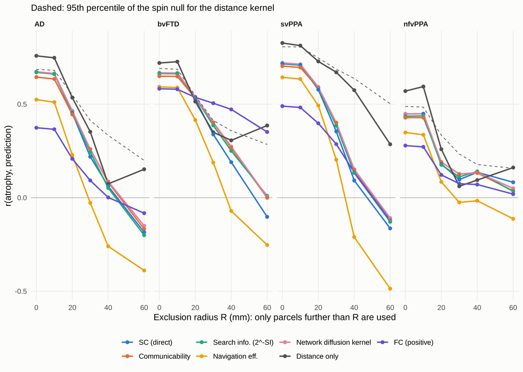

```r
cens_models <- c("SC_direct", "communicability", "search_prob", "navigation", "heat", "distance", "FC")
cz <- mt4 %>% filter(model %in% cens_models, syndrome %in% primary) %>%
  mutate(model = factor(model_labels[model], model_labels[cens_models]), syndrome = factor(syndrome, primary))
cz_band <- c4$spin %>% filter(model == "distance", syndrome %in% primary) %>% group_by(R, syndrome) %>%
  summarise(hi = quantile(r, 0.95, na.rm = TRUE), .groups = "drop") %>% mutate(syndrome = factor(syndrome, primary))
cat_cols <- c("#2a78d6", "#eb6834", "#1baf7a", "#eda100", "#e87ba4", "#52514e", "#6250d6")
ggplot(cz, aes(R, r, colour = model)) +
  geom_hline(yintercept = 0, colour = "#a8a79f", linewidth = 0.3) +
  geom_line(linewidth = 0.8) + geom_point(size = 1.6) +
  geom_line(data = cz_band, aes(R, hi), inherit.aes = FALSE, linetype = 2, colour = "#52514e", linewidth = 0.4) +
  scale_colour_manual(values = setNames(cat_cols, model_labels[cens_models]), name = NULL) +
  facet_wrap(~syndrome, ncol = 4) +
  labs(x = "Exclusion radius R (mm): only parcels further than R are used", y = "r(atrophy, prediction)",
       subtitle = "Dashed: 95th percentile of the spin null for the distance kernel") +
  theme(legend.position = "bottom") + guides(colour = guide_legend(nrow = 2))
```

```r
cz_tab <- mt4 %>% filter(R == 30, model %in% cens_models) %>% select(syndrome, model, r, p_spin, q_spin, p_rew_deg, p_rew_geo) %>%
  mutate(syndrome = syn_lab(syndrome)) %>% arrange(syndrome, desc(r))
cz_tab %>% mutate(across(where(is.numeric), ~ round(.x, 3)))
```

| syndrome | model | r | p_spin | q_spin | p_rew_deg | p_rew_geo |
| --- | --- | --- | --- | --- | --- | --- |
| AD | distance | 0.352 | 0.227 | 0.998 | NA | NA |
| AD | heat | 0.259 | 0.421 | 0.998 | 0.001 | 0.239 |
| AD | communicability | 0.259 | 0.398 | 0.998 | 0.001 | 0.232 |
| AD | search_prob | 0.244 | 0.397 | 0.998 | 0.001 | 0.137 |
| AD | SC_direct | 0.219 | 0.433 | 0.998 | 0.001 | 0.186 |
| AD | FC | 0.092 | 0.073 | NA | NA | NA |
| AD | navigation | -0.028 | 0.596 | 0.998 | 0.041 | 0.033 |
| MCI | distance | 0.122 | 0.543 | 0.998 | NA | NA |
| MCI | FC | -0.057 | 0.245 | NA | NA | NA |
| MCI | heat | -0.060 | 0.964 | 0.998 | 0.510 | 0.943 |
| MCI | SC_direct | -0.069 | 0.965 | 0.998 | 0.566 | 0.958 |
| MCI | search_prob | -0.071 | 0.956 | 0.998 | 0.404 | 0.878 |
| MCI | communicability | -0.082 | 0.965 | 0.998 | 0.424 | 0.929 |
| MCI | navigation | -0.283 | 0.918 | 0.998 | 0.997 | 0.199 |
| PD | heat | 0.155 | 0.116 | 0.811 | 0.001 | 0.014 |
| PD | SC_direct | 0.149 | 0.089 | 0.811 | 0.001 | 0.014 |
| PD | communicability | 0.129 | 0.144 | 0.895 | 0.001 | 0.012 |
| PD | search_prob | 0.115 | 0.182 | 0.998 | 0.002 | 0.024 |
| PD | distance | 0.087 | 0.483 | 0.998 | NA | NA |
| PD | FC | 0.001 | 0.129 | NA | NA | NA |
| PD | navigation | -0.207 | 0.551 | 0.998 | 0.934 | 0.001 |
| FTD | FC | 0.438 | 0.001 | NA | NA | NA |
| FTD | distance | 0.422 | 0.272 | 0.998 | NA | NA |
| FTD | heat | 0.289 | 0.649 | 0.998 | 0.001 | 0.996 |
| FTD | communicability | 0.287 | 0.612 | 0.998 | 0.001 | 0.972 |
| FTD | search_prob | 0.267 | 0.606 | 0.998 | 0.001 | 0.847 |
| FTD | SC_direct | 0.222 | 0.699 | 0.998 | 0.001 | 0.824 |
| FTD | navigation | 0.038 | 0.749 | 0.998 | 0.001 | 0.597 |
| bvFTD | FC | 0.505 | 0.001 | NA | NA | NA |
| bvFTD | heat | 0.403 | 0.072 | 0.811 | 0.001 | 0.005 |
| bvFTD | communicability | 0.402 | 0.060 | 0.811 | 0.001 | 0.005 |
| bvFTD | search_prob | 0.386 | 0.066 | 0.811 | 0.001 | 0.007 |
| bvFTD | distance | 0.350 | 0.279 | 0.998 | NA | NA |
| bvFTD | SC_direct | 0.338 | 0.110 | 0.811 | 0.001 | 0.016 |
| bvFTD | navigation | 0.188 | 0.241 | 0.998 | 0.001 | 0.001 |
| svPPA | distance | 0.670 | 0.099 | 0.811 | NA | NA |
| svPPA | heat | 0.400 | 0.847 | 0.998 | 0.001 | 1.000 |
| svPPA | communicability | 0.400 | 0.821 | 0.998 | 0.001 | 1.000 |
| svPPA | search_prob | 0.385 | 0.786 | 0.998 | 0.001 | 0.993 |
| svPPA | SC_direct | 0.354 | 0.804 | 0.998 | 0.001 | 0.970 |
| svPPA | FC | 0.286 | 0.007 | NA | NA | NA |
| svPPA | navigation | 0.203 | 0.787 | 0.998 | 0.001 | 0.715 |
| nfvPPA | heat | 0.126 | 0.406 | 0.998 | 0.003 | 0.056 |
| nfvPPA | communicability | 0.126 | 0.372 | 0.998 | 0.001 | 0.042 |
| nfvPPA | search_prob | 0.111 | 0.399 | 0.998 | 0.002 | 0.092 |
| nfvPPA | SC_direct | 0.097 | 0.414 | 0.998 | 0.018 | 0.092 |
| nfvPPA | FC | 0.075 | 0.041 | NA | NA | NA |
| nfvPPA | distance | 0.061 | 0.781 | 0.998 | NA | NA |
| nfvPPA | navigation | -0.025 | 0.445 | 0.998 | 0.128 | 0.002 |

```r
vsD30 <- difference_table(c4, ref = "distance", models = c("SC_direct", "communicability", "search_prob", "navigation", "heat", "FC")) %>% filter(R == 30)
vsD30 %>% select(syndrome, model, r, r_distance = r_ref, diff, p_spin, q_spin) %>% mutate(syndrome = syn_lab(syndrome)) %>% arrange(syndrome, desc(diff)) %>% mutate(across(where(is.numeric), ~ round(.x, 3)))
```

| syndrome | model | r | r_distance | diff | p_spin | q_spin |
| --- | --- | --- | --- | --- | --- | --- |
| AD | heat | 0.259 | 0.352 | -0.093 | 0.520 | 0.959 |
| AD | communicability | 0.259 | 0.352 | -0.093 | 0.536 | 0.959 |
| AD | search_prob | 0.244 | 0.352 | -0.109 | 0.493 | 0.959 |
| AD | SC_direct | 0.219 | 0.352 | -0.133 | 0.421 | 0.959 |
| AD | FC | 0.092 | 0.352 | -0.260 | 0.820 | 0.959 |
| AD | navigation | -0.028 | 0.352 | -0.380 | 0.324 | 0.850 |
| MCI | FC | -0.057 | 0.122 | -0.180 | 0.741 | 0.959 |
| MCI | heat | -0.060 | 0.122 | -0.182 | 0.130 | 0.562 |
| MCI | SC_direct | -0.069 | 0.122 | -0.191 | 0.119 | 0.562 |
| MCI | search_prob | -0.071 | 0.122 | -0.193 | 0.124 | 0.562 |
| MCI | communicability | -0.082 | 0.122 | -0.204 | 0.104 | 0.562 |
| MCI | navigation | -0.283 | 0.122 | -0.405 | 0.120 | 0.562 |
| PD | heat | 0.155 | 0.087 | 0.068 | 0.580 | 0.959 |
| PD | SC_direct | 0.149 | 0.087 | 0.062 | 0.609 | 0.959 |
| PD | communicability | 0.129 | 0.087 | 0.042 | 0.749 | 0.959 |
| PD | search_prob | 0.115 | 0.087 | 0.028 | 0.845 | 0.959 |
| PD | FC | 0.001 | 0.087 | -0.086 | 0.843 | 0.959 |
| PD | navigation | -0.207 | 0.087 | -0.294 | 0.421 | 0.959 |
| FTD | FC | 0.438 | 0.422 | 0.016 | 1.000 | 1.000 |
| FTD | heat | 0.289 | 0.422 | -0.134 | 0.245 | 0.747 |
| FTD | communicability | 0.287 | 0.422 | -0.135 | 0.267 | 0.747 |
| FTD | search_prob | 0.267 | 0.422 | -0.155 | 0.265 | 0.747 |
| FTD | SC_direct | 0.222 | 0.422 | -0.200 | 0.185 | 0.647 |
| FTD | navigation | 0.038 | 0.422 | -0.385 | 0.166 | 0.633 |
| bvFTD | FC | 0.505 | 0.350 | 0.155 | 0.943 | 0.999 |
| bvFTD | heat | 0.403 | 0.350 | 0.053 | 0.679 | 0.959 |
| bvFTD | communicability | 0.402 | 0.350 | 0.052 | 0.683 | 0.959 |
| bvFTD | search_prob | 0.386 | 0.350 | 0.037 | 0.783 | 0.959 |
| bvFTD | SC_direct | 0.338 | 0.350 | -0.011 | 0.930 | 0.999 |
| bvFTD | navigation | 0.188 | 0.350 | -0.162 | 0.637 | 0.959 |
| svPPA | heat | 0.400 | 0.670 | -0.270 | 0.059 | 0.562 |
| svPPA | communicability | 0.400 | 0.670 | -0.270 | 0.065 | 0.562 |
| svPPA | search_prob | 0.385 | 0.670 | -0.285 | 0.099 | 0.562 |
| svPPA | SC_direct | 0.354 | 0.670 | -0.316 | 0.076 | 0.562 |
| svPPA | FC | 0.286 | 0.670 | -0.384 | 0.951 | 0.999 |
| svPPA | navigation | 0.203 | 0.670 | -0.467 | 0.134 | 0.562 |
| nfvPPA | heat | 0.126 | 0.061 | 0.065 | 0.558 | 0.959 |
| nfvPPA | communicability | 0.126 | 0.061 | 0.065 | 0.578 | 0.959 |
| nfvPPA | search_prob | 0.111 | 0.061 | 0.050 | 0.667 | 0.959 |
| nfvPPA | SC_direct | 0.097 | 0.061 | 0.036 | 0.761 | 0.959 |
| nfvPPA | FC | 0.075 | 0.061 | 0.014 | 0.984 | 1.000 |
| nfvPPA | navigation | -0.025 | 0.061 | -0.086 | 0.717 | 0.959 |

At R = 30 mm the SC-direct model drops nodes that have no SC edge longer than 30 mm (4 of 400 at Schaefer-400).

## 11.2 Unique contribution beyond distance

Partial correlation r(a, P_M | P_distance), with the distance kernel refitted for every map and spin surrogate (null: 1,000 spins).

```r
pm <- c("SC_direct", "communicability", "search_prob", "navigation", "FC")
Mlist <- c(communication_models(d4$SC, d4$Dist)[setdiff(pm, "FC")], list(FC = d4$FC))
As4 <- do.call(cbind, lapply(syn, function(s) spin_maps(d4$A[, s], c4$perms)))
part <- do.call(rbind, lapply(c(0, 30), function(R) do.call(rbind, lapply(pm, function(m) {
  obs <- partial_beyond_distance(Mlist[[m]], d4$A, d4$Dist, R)
  nul <- matrix(partial_beyond_distance(Mlist[[m]], As4, d4$Dist, R), ncol = length(syn))
  data.frame(R = R, model = m, syndrome = syn, partial_r = obs,
             p_spin = sapply(seq_along(syn), function(i) p_upper(obs[i], nul[, i])))
}))))
part$q_spin <- ave(part$p_spin, part$R, FUN = function(p) p.adjust(p, "BH")); rownames(part) <- NULL
part %>% mutate(syndrome = syn_lab(syndrome)) %>% arrange(R, syndrome, desc(partial_r)) %>% mutate(across(where(is.numeric), ~ round(.x, 3)))
```

| R | model | syndrome | partial_r | p_spin | q_spin |
| --- | --- | --- | --- | --- | --- |
| 0 | FC | AD | 0.106 | 0.017 | 0.149 |
| 0 | SC_direct | AD | 0.104 | 0.378 | 0.932 |
| 0 | search_prob | AD | 0.097 | 0.402 | 0.932 |
| 0 | communicability | AD | 0.066 | 0.469 | 0.932 |
| 0 | navigation | AD | -0.051 | 0.880 | 0.932 |
| 0 | FC | MCI | 0.052 | 0.089 | 0.622 |
| 0 | SC_direct | MCI | 0.022 | 0.834 | 0.932 |
| 0 | search_prob | MCI | 0.008 | 0.888 | 0.932 |
| 0 | communicability | MCI | -0.012 | 0.919 | 0.932 |
| 0 | navigation | MCI | -0.056 | 0.882 | 0.932 |
| 0 | FC | PD | 0.019 | 0.215 | 0.683 |
| 0 | search_prob | PD | -0.004 | 0.894 | 0.932 |
| 0 | SC_direct | PD | -0.008 | 0.912 | 0.932 |
| 0 | communicability | PD | -0.013 | 0.895 | 0.932 |
| 0 | navigation | PD | -0.057 | 0.761 | 0.932 |
| 0 | FC | FTD | 0.179 | 0.001 | 0.035 |
| 0 | SC_direct | FTD | 0.065 | 0.628 | 0.932 |
| 0 | search_prob | FTD | 0.057 | 0.663 | 0.932 |
| 0 | communicability | FTD | 0.042 | 0.638 | 0.932 |
| 0 | navigation | FTD | -0.008 | 0.641 | 0.932 |
| 0 | FC | bvFTD | 0.233 | 0.002 | 0.035 |
| 0 | SC_direct | bvFTD | 0.147 | 0.155 | 0.683 |
| 0 | search_prob | bvFTD | 0.139 | 0.164 | 0.683 |
| 0 | communicability | bvFTD | 0.108 | 0.180 | 0.683 |
| 0 | navigation | bvFTD | 0.048 | 0.116 | 0.676 |
| 0 | FC | svPPA | 0.127 | 0.008 | 0.093 |
| 0 | search_prob | svPPA | 0.016 | 0.913 | 0.932 |
| 0 | SC_direct | svPPA | 0.012 | 0.932 | 0.932 |
| 0 | communicability | svPPA | 0.007 | 0.916 | 0.932 |
| 0 | navigation | svPPA | -0.019 | 0.883 | 0.932 |
| 0 | FC | nfvPPA | 0.027 | 0.204 | 0.683 |
| 0 | SC_direct | nfvPPA | 0.021 | 0.778 | 0.932 |
| 0 | search_prob | nfvPPA | -0.007 | 0.891 | 0.932 |
| 0 | communicability | nfvPPA | -0.012 | 0.873 | 0.932 |
| 0 | navigation | nfvPPA | -0.044 | 0.817 | 0.932 |
| 30 | FC | AD | 0.172 | 0.011 | 0.096 |
| 30 | communicability | AD | 0.086 | 0.537 | 0.784 |
| 30 | search_prob | AD | 0.084 | 0.544 | 0.784 |
| 30 | SC_direct | AD | 0.071 | 0.581 | 0.784 |
| 30 | navigation | AD | -0.190 | 0.712 | 0.805 |
| 30 | FC | MCI | -0.050 | 0.214 | 0.576 |
| 30 | SC_direct | MCI | -0.104 | 0.950 | 0.950 |
| 30 | search_prob | MCI | -0.113 | 0.945 | 0.950 |
| 30 | communicability | MCI | -0.125 | 0.945 | 0.950 |
| 30 | navigation | MCI | -0.308 | 0.933 | 0.950 |
| 30 | SC_direct | PD | 0.130 | 0.097 | 0.424 |
| 30 | communicability | PD | 0.105 | 0.163 | 0.518 |
| 30 | search_prob | PD | 0.092 | 0.198 | 0.576 |
| 30 | FC | PD | -0.001 | 0.123 | 0.430 |
| 30 | navigation | PD | -0.215 | 0.523 | 0.784 |
| 30 | FC | FTD | 0.377 | 0.001 | 0.012 |
| 30 | communicability | FTD | 0.163 | 0.361 | 0.664 |
| 30 | search_prob | FTD | 0.159 | 0.335 | 0.651 |
| 30 | SC_direct | FTD | 0.132 | 0.404 | 0.706 |
| 30 | navigation | FTD | -0.077 | 0.646 | 0.805 |
| 30 | FC | bvFTD | 0.446 | 0.001 | 0.012 |
| 30 | communicability | bvFTD | 0.272 | 0.079 | 0.424 |
| 30 | search_prob | bvFTD | 0.265 | 0.085 | 0.424 |
| 30 | SC_direct | bvFTD | 0.230 | 0.112 | 0.430 |
| 30 | navigation | bvFTD | 0.029 | 0.244 | 0.609 |
| 30 | FC | svPPA | 0.264 | 0.001 | 0.012 |
| 30 | search_prob | svPPA | 0.132 | 0.641 | 0.805 |
| 30 | communicability | svPPA | 0.120 | 0.713 | 0.805 |
| 30 | SC_direct | svPPA | 0.110 | 0.691 | 0.805 |
| 30 | navigation | svPPA | 0.027 | 0.582 | 0.784 |
| 30 | communicability | nfvPPA | 0.112 | 0.264 | 0.615 |
| 30 | search_prob | nfvPPA | 0.098 | 0.295 | 0.623 |
| 30 | SC_direct | nfvPPA | 0.087 | 0.303 | 0.623 |
| 30 | FC | nfvPPA | 0.061 | 0.039 | 0.273 |
| 30 | navigation | nfvPPA | -0.075 | 0.434 | 0.723 |

## 11.3 Comparing null models

The same tests under five nulls. Spatial nulls (spin, variogram-matched, Moran) preserve the map’s spatial autocorrelation; rewiring nulls keep the map and replace the SC by degree-preserving or degree-and-geometry-preserving surrogates.

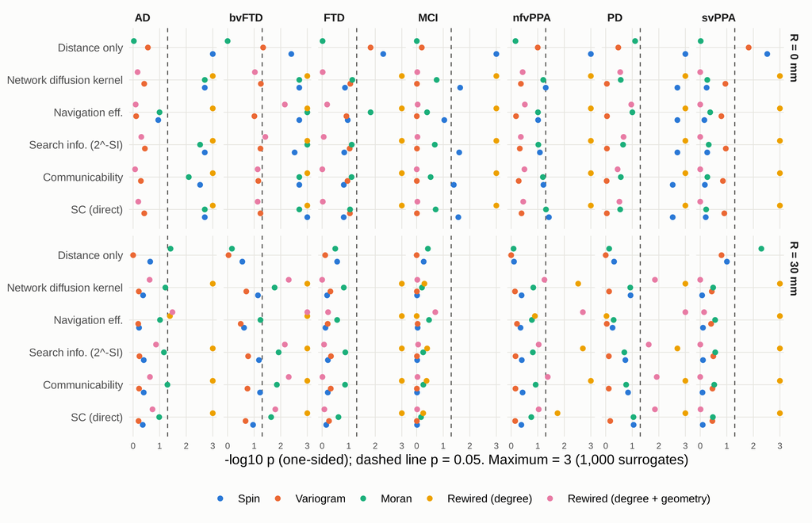

```r
nl_models <- c("SC_direct", "communicability", "search_prob", "navigation", "heat", "distance")
nl <- mt4 %>% filter(R %in% c(0, 30), model %in% nl_models) %>%
  select(R, model, syndrome, p_spin, p_variogram, p_moran, p_rew_deg, p_rew_geo) %>%
  pivot_longer(starts_with("p_"), names_to = "null", values_to = "p") %>%
  mutate(null = factor(recode(null, p_spin = "Spin", p_variogram = "Variogram", p_moran = "Moran",
                              p_rew_deg = "Rewired (degree)", p_rew_geo = "Rewired (degree + geometry)"),
                       c("Spin", "Variogram", "Moran", "Rewired (degree)", "Rewired (degree + geometry)")),
         model = factor(model_labels[model], model_labels[nl_models]), Rl = paste0("R = ", R, " mm"))
ggplot(nl %>% filter(!is.na(p)), aes(-log10(p), model, colour = null)) +
  geom_vline(xintercept = -log10(0.05), linetype = 2, colour = "#52514e", linewidth = 0.4) +
  geom_point(position = position_dodge(width = 0.6), size = 1.5) +
  scale_colour_manual(values = setNames(cat_cols[1:5], levels(nl$null)), name = NULL) +
  facet_grid(Rl ~ syndrome) +
  labs(x = "-log10 p (one-sided); dashed line p = 0.05. Maximum = 3 (1,000 surrogates)", y = NULL) +
  theme(legend.position = "bottom", axis.text.x = element_text(size = 7))
```

```r
nl %>% filter(!is.na(p)) %>% group_by(R, null) %>% summarise(tests = n(), significant_p05 = sum(p < 0.05), median_p = median(p), .groups = "drop")
```

| R | null | tests | significant_p05 | median_p |
| --- | --- | --- | --- | --- |
| 0 | Spin | 42 | 27 | 0.0139860 |
| 0 | Variogram | 42 | 3 | 0.3476523 |
| 0 | Moran | 42 | 11 | 0.0999001 |
| 0 | Rewired (degree) | 35 | 35 | 0.0009990 |
| 0 | Rewired (degree + geometry) | 35 | 2 | 0.6483516 |
| 30 | Spin | 42 | 0 | 0.4385614 |
| 30 | Variogram | 42 | 0 | 0.6308691 |
| 30 | Moran | 42 | 6 | 0.1678322 |
| 30 | Rewired (degree) | 35 | 28 | 0.0009990 |
| 30 | Rewired (degree + geometry) | 35 | 13 | 0.1858142 |

**Why the spatial nulls disagree.** A null for neighbour-based statistics must reproduce the map’s *short-range* autocorrelation. The table compares, for each null, the surrogates’ variogram in the five shortest distance bins (ratio to the empirical variogram; 1 = preserved, > 1 = rougher than the real map) and the correlation between each parcel and its nearest neighbour (200 surrogates per syndrome).

```r
vs4 <- variogram_setup(d4$Dist)
nn4 <- apply(d4$Dist + diag(Inf, nrow(d4$Dist)), 1, which.min)
nd <- do.call(rbind, lapply(seq_along(syn), function(i) {
  x <- d4$A[, i]; g <- drop(variogram(x, vs4))
  sets <- list(Spin = spin_maps(x, c4$perms[, 1:200]), Variogram = sur_v[[i]][, 1:200], Moran = sur_m[[i]][, 1:200])
  data.frame(syndrome = syn[i], null = names(sets),
             short_range_variogram_ratio = sapply(sets, function(X) mean(rowMeans(variogram(X, vs4))[1:5] / g[1:5])),
             nn_corr_null_median = sapply(sets, function(X) median(colcor(X, X[nn4, , drop = FALSE]))),
             nn_corr_observed = cor(x, x[nn4]))
}))
rownames(nd) <- NULL
nd %>% mutate(syndrome = syn_lab(syndrome)) %>% arrange(syndrome, null) %>% mutate(across(where(is.numeric), ~ round(.x, 2)))
```

| syndrome | null | short_range_variogram_ratio | nn_corr_null_median | nn_corr_observed |
| --- | --- | --- | --- | --- |
| AD | Moran | 0.98 | 0.65 | 0.62 |
| AD | Spin | 1.51 | 0.45 | 0.62 |
| AD | Variogram | 1.13 | 0.58 | 0.62 |
| MCI | Moran | 0.90 | 0.58 | 0.51 |
| MCI | Spin | 1.29 | 0.35 | 0.51 |
| MCI | Variogram | 0.92 | 0.53 | 0.51 |
| PD | Moran | 0.90 | 0.46 | 0.46 |
| PD | Spin | 1.23 | 0.21 | 0.46 |
| PD | Variogram | 0.97 | 0.38 | 0.46 |
| FTD | Moran | 0.84 | 0.63 | 0.57 |
| FTD | Spin | 1.09 | 0.49 | 0.57 |
| FTD | Variogram | 1.15 | 0.45 | 0.57 |
| bvFTD | Moran | 0.85 | 0.62 | 0.55 |
| bvFTD | Spin | 1.11 | 0.45 | 0.55 |
| bvFTD | Variogram | 1.11 | 0.43 | 0.55 |
| svPPA | Moran | 0.91 | 0.73 | 0.70 |
| svPPA | Spin | 1.30 | 0.61 | 0.70 |
| svPPA | Variogram | 1.39 | 0.56 | 0.70 |
| nfvPPA | Moran | 0.87 | 0.44 | 0.39 |
| nfvPPA | Spin | 1.02 | 0.26 | 0.39 |
| nfvPPA | Variogram | 0.98 | 0.30 | 0.39 |

## 11.4 Geometric vs connectome eigenmodes

Each atrophy map is reconstructed from the first K eigenmodes of three bases: Laplace–Beltrami eigenmodes of the cortical surface (geometric, Pang et al. 2023; fsaverage5 pial surface, medial wall removed, averaged within parcels), eigenvectors of the normalised SC Laplacian (connectome harmonics), and of the FC Laplacian. Accuracy = r(a, â_K) by least squares; null: 1,000 spun maps reconstructed with the same basis.

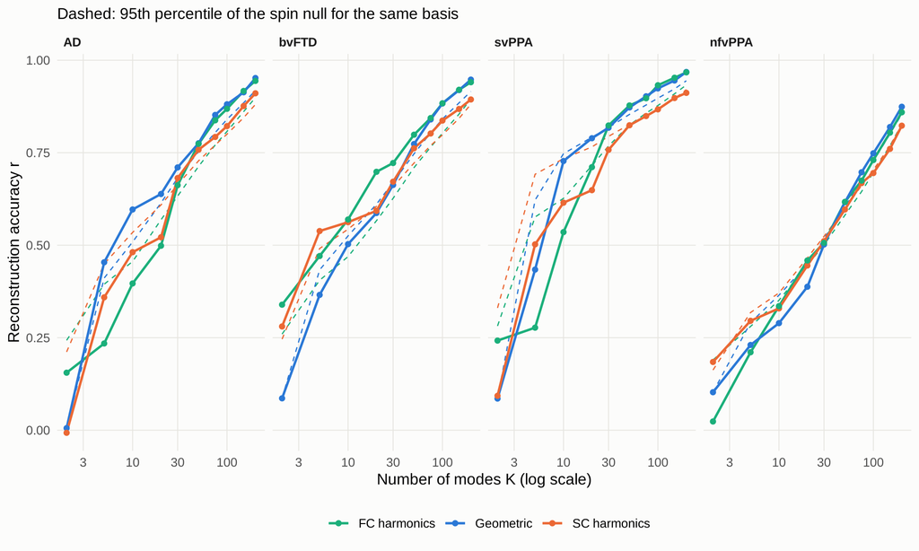

```r
eig_K <- c(2, 5, 10, 20, 30, 50, 75, 100, 150, 200)
bases <- list(Geometric = geometric_basis(400), `SC harmonics` = laplacian_modes(d4$SC)$vectors, `FC harmonics` = laplacian_modes(d4$FC)$vectors)
eg <- do.call(rbind, lapply(names(bases), function(b) {
  o <- recon_curve(bases[[b]], d4$A, eig_K)
  nl_ <- recon_curve(bases[[b]], As4, eig_K)
  do.call(rbind, lapply(seq_along(syn), function(i) {
    cols <- (i - 1) * ncol(c4$perms) + seq_len(ncol(c4$perms))
    data.frame(basis = b, syndrome = syn[i], K = eig_K, r = o[i, ],
               null_hi = apply(nl_[cols, ], 2, quantile, 0.95), p_spin = sapply(seq_along(eig_K), function(k) p_upper(o[i, k], nl_[cols, k])))
  }))
}))
ggplot(eg %>% filter(syndrome %in% primary) %>% mutate(syndrome = factor(syndrome, primary)), aes(K, r, colour = basis)) +
  geom_line(aes(y = null_hi), linetype = 2, linewidth = 0.4) +
  geom_line(linewidth = 0.8) + geom_point(size = 1.4) +
  scale_x_log10() + scale_colour_manual(values = setNames(cat_cols[c(1, 2, 3)], names(bases)), name = NULL) +
  facet_wrap(~syndrome, ncol = 4) +
  labs(x = "Number of modes K (log scale)", y = "Reconstruction accuracy r", subtitle = "Dashed: 95th percentile of the spin null for the same basis") +
  theme(legend.position = "bottom")
```

```r
eg %>% filter(K %in% c(10, 20, 50)) %>% select(basis, syndrome, K, r, p_spin) %>%
  pivot_wider(names_from = basis, values_from = c(r, p_spin)) %>% mutate(syndrome = syn_lab(syndrome)) %>% arrange(K, syndrome) %>%
  mutate(across(where(is.numeric), ~ round(.x, 3)))
```

| syndrome | K | r_Geometric | r_SC harmonics | r_FC harmonics | p_spin_Geometric | p_spin_SC harmonics | p_spin_FC harmonics |
| --- | --- | --- | --- | --- | --- | --- | --- |
| AD | 10 | 0.597 | 0.481 | 0.397 | 0.001 | 0.318 | 0.249 |
| MCI | 10 | 0.453 | 0.325 | 0.254 | 0.005 | 0.557 | 0.614 |
| PD | 10 | 0.351 | 0.381 | 0.265 | 0.014 | 0.039 | 0.183 |
| FTD | 10 | 0.550 | 0.514 | 0.550 | 0.200 | 0.448 | 0.005 |
| bvFTD | 10 | 0.503 | 0.562 | 0.569 | 0.116 | 0.015 | 0.001 |
| svPPA | 10 | 0.728 | 0.615 | 0.535 | 0.160 | 0.792 | 0.288 |
| nfvPPA | 10 | 0.289 | 0.329 | 0.335 | 0.727 | 0.285 | 0.083 |
| AD | 20 | 0.638 | 0.521 | 0.499 | 0.007 | 0.744 | 0.436 |
| MCI | 20 | 0.542 | 0.361 | 0.399 | 0.008 | 0.973 | 0.472 |
| PD | 20 | 0.452 | 0.420 | 0.331 | 0.051 | 0.223 | 0.467 |
| FTD | 20 | 0.623 | 0.563 | 0.665 | 0.236 | 0.655 | 0.003 |
| bvFTD | 20 | 0.587 | 0.593 | 0.698 | 0.179 | 0.115 | 0.001 |
| svPPA | 20 | 0.789 | 0.649 | 0.711 | 0.072 | 0.952 | 0.066 |
| nfvPPA | 20 | 0.388 | 0.445 | 0.459 | 0.526 | 0.137 | 0.031 |
| AD | 50 | 0.776 | 0.758 | 0.774 | 0.002 | 0.003 | 0.002 |
| MCI | 50 | 0.680 | 0.650 | 0.653 | 0.012 | 0.029 | 0.008 |
| PD | 50 | 0.582 | 0.564 | 0.524 | 0.058 | 0.078 | 0.112 |
| FTD | 50 | 0.795 | 0.768 | 0.817 | 0.007 | 0.009 | 0.001 |
| bvFTD | 50 | 0.774 | 0.762 | 0.799 | 0.004 | 0.001 | 0.001 |
| svPPA | 50 | 0.872 | 0.824 | 0.878 | 0.002 | 0.066 | 0.001 |
| nfvPPA | 50 | 0.616 | 0.597 | 0.617 | 0.014 | 0.068 | 0.004 |

Rewiring null for the connectome harmonics (accuracy with the harmonics of rewired SCs):

```r
rec_obs <- recon_curve(laplacian_modes(d4$SC)$vectors, d4$A, harmonic_Ks)
rr <- do.call(rbind, lapply(c("rew_deg", "rew_geo"), function(nm) {
  x <- c4[[nm]]$recon # syndromes x K x B
  do.call(rbind, lapply(seq_along(syn), function(i) data.frame(null = nm, syndrome = syn[i], K = harmonic_Ks, r_obs = rec_obs[i, ],
    null_median = apply(x[i, , ], 1, median), p = sapply(seq_along(harmonic_Ks), function(k) p_upper(rec_obs[i, k], x[i, k, ])))))
}))
rr %>% filter(K %in% c(10, 20, 50)) %>% mutate(syndrome = syn_lab(syndrome)) %>% arrange(null, K, syndrome) %>% mutate(across(where(is.numeric), ~ round(.x, 3)))
```

| null | syndrome | K | r_obs | null_median | p |
| --- | --- | --- | --- | --- | --- |
| rew_deg | AD | 10 | 0.481 | 0.120 | 0.001 |
| rew_deg | MCI | 10 | 0.325 | 0.200 | 0.001 |
| rew_deg | PD | 10 | 0.381 | 0.139 | 0.001 |
| rew_deg | FTD | 10 | 0.514 | 0.286 | 0.001 |
| rew_deg | bvFTD | 10 | 0.562 | 0.327 | 0.001 |
| rew_deg | svPPA | 10 | 0.615 | 0.166 | 0.001 |
| rew_deg | nfvPPA | 10 | 0.329 | 0.222 | 0.001 |
| rew_deg | AD | 20 | 0.521 | 0.198 | 0.001 |
| rew_deg | MCI | 20 | 0.361 | 0.251 | 0.003 |
| rew_deg | PD | 20 | 0.420 | 0.209 | 0.001 |
| rew_deg | FTD | 20 | 0.563 | 0.319 | 0.001 |
| rew_deg | bvFTD | 20 | 0.593 | 0.351 | 0.001 |
| rew_deg | svPPA | 20 | 0.649 | 0.228 | 0.001 |
| rew_deg | nfvPPA | 20 | 0.445 | 0.269 | 0.001 |
| rew_deg | AD | 50 | 0.758 | 0.339 | 0.001 |
| rew_deg | MCI | 50 | 0.650 | 0.373 | 0.001 |
| rew_deg | PD | 50 | 0.564 | 0.348 | 0.001 |
| rew_deg | FTD | 50 | 0.768 | 0.412 | 0.001 |
| rew_deg | bvFTD | 50 | 0.762 | 0.434 | 0.001 |
| rew_deg | svPPA | 50 | 0.824 | 0.358 | 0.001 |
| rew_deg | nfvPPA | 50 | 0.597 | 0.380 | 0.001 |
| rew_geo | AD | 10 | 0.481 | 0.411 | 0.005 |
| rew_geo | MCI | 10 | 0.325 | 0.347 | 0.774 |
| rew_geo | PD | 10 | 0.381 | 0.330 | 0.003 |
| rew_geo | FTD | 10 | 0.514 | 0.577 | 1.000 |
| rew_geo | bvFTD | 10 | 0.562 | 0.550 | 0.099 |
| rew_geo | svPPA | 10 | 0.615 | 0.693 | 0.999 |
| rew_geo | nfvPPA | 10 | 0.329 | 0.320 | 0.175 |
| rew_geo | AD | 20 | 0.521 | 0.628 | 1.000 |
| rew_geo | MCI | 20 | 0.361 | 0.529 | 1.000 |
| rew_geo | PD | 20 | 0.420 | 0.463 | 0.994 |
| rew_geo | FTD | 20 | 0.563 | 0.673 | 1.000 |
| rew_geo | bvFTD | 20 | 0.593 | 0.641 | 0.999 |
| rew_geo | svPPA | 20 | 0.649 | 0.771 | 1.000 |
| rew_geo | nfvPPA | 20 | 0.445 | 0.396 | 0.003 |
| rew_geo | AD | 50 | 0.758 | 0.746 | 0.206 |
| rew_geo | MCI | 50 | 0.650 | 0.660 | 0.727 |
| rew_geo | PD | 50 | 0.564 | 0.562 | 0.451 |
| rew_geo | FTD | 50 | 0.768 | 0.757 | 0.150 |
| rew_geo | bvFTD | 50 | 0.762 | 0.730 | 0.004 |
| rew_geo | svPPA | 50 | 0.824 | 0.830 | 0.734 |
| rew_geo | nfvPPA | 50 | 0.597 | 0.580 | 0.206 |

## 11.5 Smoothness of atrophy on the SC

Normalised Dirichlet energy aᵀLa / aᵀa of the z-scored map on the SC graph (lower = atrophy varies less across strong connections).

```r
sm_obs <- graph_smoothness(d4$SC, d4$A)
sm_spin <- matrix(graph_smoothness(d4$SC, As4), ncol = length(syn))
sm <- data.frame(syndrome = syn, energy = sm_obs,
                 p_spin = sapply(seq_along(syn), function(i) (1 + sum(sm_spin[, i] <= sm_obs[i])) / (1 + nrow(sm_spin))),
                 p_rew_deg = sapply(seq_along(syn), function(i) (1 + sum(c4$rew_deg$smooth[i, ] <= sm_obs[i])) / (1 + ncol(c4$rew_deg$smooth))),
                 p_rew_geo = sapply(seq_along(syn), function(i) (1 + sum(c4$rew_geo$smooth[i, ] <= sm_obs[i])) / (1 + ncol(c4$rew_geo$smooth))))
sm %>% mutate(across(where(is.numeric), ~ round(.x, 3)))
```

|  | syndrome | energy | p_spin | p_rew_deg | p_rew_geo |
| --- | --- | --- | --- | --- | --- |
| AD | AD | 0.693 | 0.035 | 0.001 | 0.001 |
| MCI | MCI | 0.817 | 0.201 | 0.001 | 0.683 |
| PD | PD | 0.852 | 0.013 | 0.001 | 0.019 |
| FTD | FTD | 0.687 | 0.333 | 0.001 | 0.772 |
| bvFTD | bvFTD | 0.661 | 0.005 | 0.001 | 0.001 |
| svPPA | svPPA | 0.597 | 0.762 | 0.001 | 0.905 |
| nfvPPA | nfvPPA | 0.842 | 0.091 | 0.001 | 0.018 |

## 11.6 Hemispheric asymmetry

Comparing a left parcel with a right parcel is biased because Schaefer parcels are not mirror pairs (sizes and positions differ). Here each left parcel is compared with the *identical region mirrored to the right*: the voxel map is mirrored on the symmetric template and parcellated with the same atlas, so both values come from the same geometry. Asymmetry = (left − right) / SD of the map; summarised over all left parcels and over the most atrophic 20% of locations (either side), with a sign test.

```r
lat <- voxel_laterality(400)
lh4 <- d4$info$hemi == "LH"
asy <- do.call(rbind, lapply(syn, function(s) {
  a <- d4$A[, s]; f <- c4$flipped[, s]; thr <- quantile(a, 0.8); sel <- lh4 & (a >= thr | f >= thr)
  data.frame(syndrome = s, voxel_mirror_r = lat$mirror_r[lat$syndrome == s], voxel_LI = lat$LI_positive_atrophy[lat$syndrome == s],
             mean_LminusR_SD = mean(a[lh4] - f[lh4]) / sd(a), top20_LminusR_SD = mean(a[sel] - f[sel]) / sd(a),
             top20_left_greater = mean(a[sel] > f[sel]), sign_test_p = binom.test(sum(a[sel] > f[sel]), sum(sel))$p.value,
             most_left_biased = short_label(d4$info$label[lh4][which.max(a[lh4] - f[lh4])]))
}))
asy %>% mutate(across(where(is.numeric), ~ round(.x, 3)))
```

| syndrome | voxel_mirror_r | voxel_LI | mean_LminusR_SD | top20_LminusR_SD | top20_left_greater | sign_test_p | most_left_biased |
| --- | --- | --- | --- | --- | --- | --- | --- |
| AD | 0.740 | -0.022 | 0.026 | -0.021 | 0.491 | 1.000 | LH_DorsAttn_Post_14 |
| MCI | 0.543 | -0.027 | -0.054 | -0.136 | 0.429 | 0.314 | LH_SomMot_7 |
| PD | 0.231 | -0.043 | -0.144 | -0.348 | 0.422 | 0.260 | LH_Cont_Par_2 |
| FTD | 0.804 | 0.027 | 0.073 | 0.342 | 0.761 | 0.001 | LH_Cont_PFCv_1 |
| bvFTD | 0.759 | -0.058 | -0.108 | -0.058 | 0.381 | 0.164 | LH_SomMot_15 |
| svPPA | 0.764 | 0.109 | 0.214 | 0.536 | 0.840 | 0.000 | LH_Cont_PFCv_1 |
| nfvPPA | 0.441 | 0.110 | 0.235 | 0.386 | 0.667 | 0.008 | LH_Default_pCunPCC_4 |

## 11.7 MCI

```r
zd <- as.numeric(scale(d4$A[, "MCI"]) - scale(d4$A[, "AD"]))
net_mci <- aggregate(cbind(AD = d4$A[, "AD"], MCI = d4$A[, "MCI"]) ~ network, data = data.frame(network = d4$info$network, d4$A), FUN = mean)
list(similarity = c(r_MCI_AD = round(cor(d4$A[, "MCI"], d4$A[, "AD"]), 3),
                    slope_MCI_on_AD = round(unname(coef(lm(d4$A[, "MCI"] ~ d4$A[, "AD"]))[2]), 3)),
     relatively_more_in_MCI = short_label(d4$info$label[order(-zd)[1:6]]),
     relatively_less_in_MCI = short_label(d4$info$label[order(zd)[1:6]]),
     network_means = net_mci %>% mutate(MCI_over_AD = MCI / AD) %>% mutate(across(where(is.numeric), ~ round(.x, 2))))
```

```
## $similarity
##        r_MCI_AD slope_MCI_on_AD
##           0.799           0.660
##
## $relatively_more_in_MCI
## [1] "LH_Default_pCunPCC_4"  "LH_SomMot_19"          "LH_SomMot_32"
## [4] "LH_SomMot_23"          "RH_DorsAttn_Post_18"   "RH_Default_PFCdPFCm_6"
##
## $relatively_less_in_MCI
## [1] "LH_Cont_Par_3"        "LH_Cont_Par_2"        "LH_Vis_20"
## [4] "RH_SomMot_8"          "LH_Limbic_TempPole_4" "LH_Default_Temp_8"
##
## $network_means
##       network    AD  MCI MCI_over_AD
## 1        Cont  0.42 0.51        1.23
## 2     Default  0.78 0.78        0.99
## 3    DorsAttn  0.64 0.61        0.96
## 4      Limbic  1.45 1.32        0.91
## 5 SalVentAttn  0.60 0.80        1.33
## 6      SomMot -0.21 0.18       -0.87
## 7         Vis  0.69 0.40        0.58
```

The MCI map has the AD topography (r = 0.80) at about two-thirds of its amplitude. Its epicentres are medial temporal and posterior cingulate/precuneus parcels (table in “D. Epicentres”); relative to AD it is weaker in visual, lateral temporal and parietal cortex and relatively stronger in posterior cingulate/precuneus, somatomotor, salience and control parcels. Network results follow AD but are weaker: SC-neighbour r = 0.53 (spin p = 0.03, not significant under variogram or geometry-preserving nulls), no FC contribution beyond distance, and no long-range predictability (r ≤ 0.12 when only parcels > 30 mm away are used). ADNI MCI was not selected on amyloid status, so the map mixes prodromal AD with other causes.

## 11.8 Robustness across resolutions

```r
rob <- do.call(rbind, lapply(names(CC), function(k) {
  mt <- model_table(CC[[k]])
  x <- mt %>% filter(R == 0, model %in% c("SC_direct", "FC", "distance", "heat", "communicability", "search_prob")) %>% select(model, syndrome, r, q_spin, q_rew_deg)
  x$parcels <- as.integer(k); x
}))
rob %>% select(parcels, syndrome, model, r) %>% pivot_wider(names_from = parcels, values_from = r, names_prefix = "r_") %>%
  mutate(syndrome = syn_lab(syndrome)) %>% arrange(syndrome, model) %>% mutate(across(where(is.numeric), ~ round(.x, 3)))
```

| syndrome | model | r_100 | r_200 | r_400 |
| --- | --- | --- | --- | --- |
| AD | FC | 0.313 | 0.364 | 0.374 |
| AD | SC_direct | 0.520 | 0.565 | 0.671 |
| AD | communicability | 0.472 | 0.534 | 0.644 |
| AD | distance | 0.656 | 0.673 | 0.758 |
| AD | heat | 0.521 | 0.567 | 0.674 |
| AD | search_prob | 0.503 | 0.564 | 0.670 |
| MCI | FC | 0.175 | 0.249 | 0.265 |
| MCI | SC_direct | 0.357 | 0.381 | 0.526 |
| MCI | communicability | 0.311 | 0.341 | 0.501 |
| MCI | distance | 0.607 | 0.564 | 0.680 |
| MCI | heat | 0.362 | 0.383 | 0.531 |
| MCI | search_prob | 0.354 | 0.386 | 0.526 |
| PD | FC | 0.187 | 0.159 | 0.227 |
| PD | SC_direct | 0.228 | 0.396 | 0.431 |
| PD | communicability | 0.186 | 0.370 | 0.421 |
| PD | distance | 0.350 | 0.482 | 0.598 |
| PD | heat | 0.225 | 0.397 | 0.435 |
| PD | search_prob | 0.182 | 0.376 | 0.437 |
| FTD | FC | 0.580 | 0.566 | 0.537 |
| FTD | SC_direct | 0.509 | 0.619 | 0.645 |
| FTD | communicability | 0.496 | 0.598 | 0.631 |
| FTD | distance | 0.706 | 0.701 | 0.738 |
| FTD | heat | 0.509 | 0.617 | 0.649 |
| FTD | search_prob | 0.509 | 0.621 | 0.644 |
| bvFTD | FC | 0.647 | 0.592 | 0.582 |
| bvFTD | SC_direct | 0.581 | 0.604 | 0.665 |
| bvFTD | communicability | 0.569 | 0.590 | 0.649 |
| bvFTD | distance | 0.691 | 0.656 | 0.720 |
| bvFTD | heat | 0.579 | 0.602 | 0.667 |
| bvFTD | search_prob | 0.574 | 0.607 | 0.664 |
| svPPA | FC | 0.455 | 0.525 | 0.489 |
| svPPA | SC_direct | 0.588 | 0.685 | 0.715 |
| svPPA | communicability | 0.570 | 0.667 | 0.703 |
| svPPA | distance | 0.778 | 0.823 | 0.827 |
| svPPA | heat | 0.591 | 0.689 | 0.721 |
| svPPA | search_prob | 0.594 | 0.686 | 0.718 |
| nfvPPA | FC | 0.237 | 0.259 | 0.279 |
| nfvPPA | SC_direct | 0.265 | 0.439 | 0.448 |
| nfvPPA | communicability | 0.259 | 0.423 | 0.428 |
| nfvPPA | distance | 0.548 | 0.533 | 0.570 |
| nfvPPA | heat | 0.259 | 0.442 | 0.447 |
| nfvPPA | search_prob | 0.261 | 0.444 | 0.436 |

```r
rob_vsD <- do.call(rbind, lapply(names(CC), function(k) {
  x <- difference_table(CC[[k]], ref = "distance", models = setdiff(E_models, "distance"), nulls = "spin") %>% filter(R %in% c(0, 30))
  x$parcels <- as.integer(k); x
}))
rob_vsD %>% group_by(parcels, R) %>% summarise(tests = n(), model_better_q05 = sum(diff > 0 & q_spin < 0.05), model_worse_q05 = sum(diff < 0 & q_spin < 0.05), .groups = "drop")
```

| parcels | R | tests | model_better_q05 | model_worse_q05 |
| --- | --- | --- | --- | --- |
| 100 | 0 | 49 | 0 | 2 |
| 100 | 30 | 49 | 0 | 1 |
| 200 | 0 | 49 | 0 | 6 |
| 200 | 30 | 49 | 0 | 0 |
| 400 | 0 | 49 | 0 | 13 |
| 400 | 30 | 49 | 0 | 0 |

# 12 Brain maps

Parcel results drawn on the fsaverage5 inflated surface (sulcal depth in grey), using the same Schaefer-400 parcels and ENIGMA annotations as the analysis; rendered by `scripts/05_brain_figures.py` from values exported by `scripts/04_export_maps.R`. The ENIGMA `fsa5_*.gii` surface is the pial surface (identical to nilearn’s fsaverage5 pial).

**The atlas as used.** Schaefer-400, 7 networks, CBIG colours; and the volumetric atlas after nearest-neighbour resampling to the ICBM152 2009c grid of the atrophy maps.

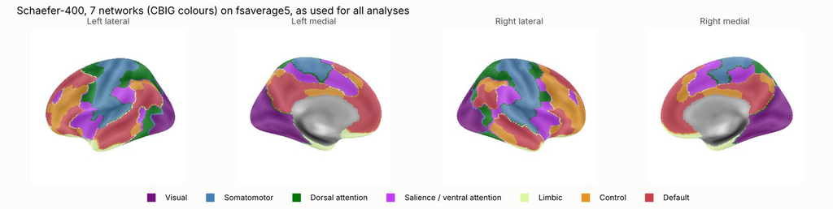

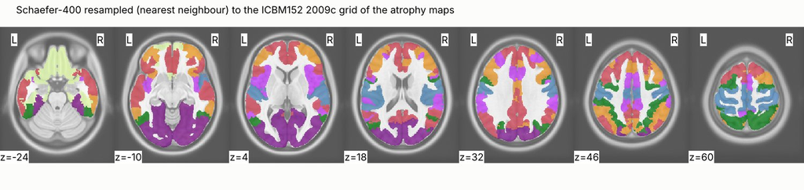

**Atrophy.** Colour scale set per syndrome because the FTD-variant maps are on a smaller scale. Below: the same parcel values painted back into the atlas volume.

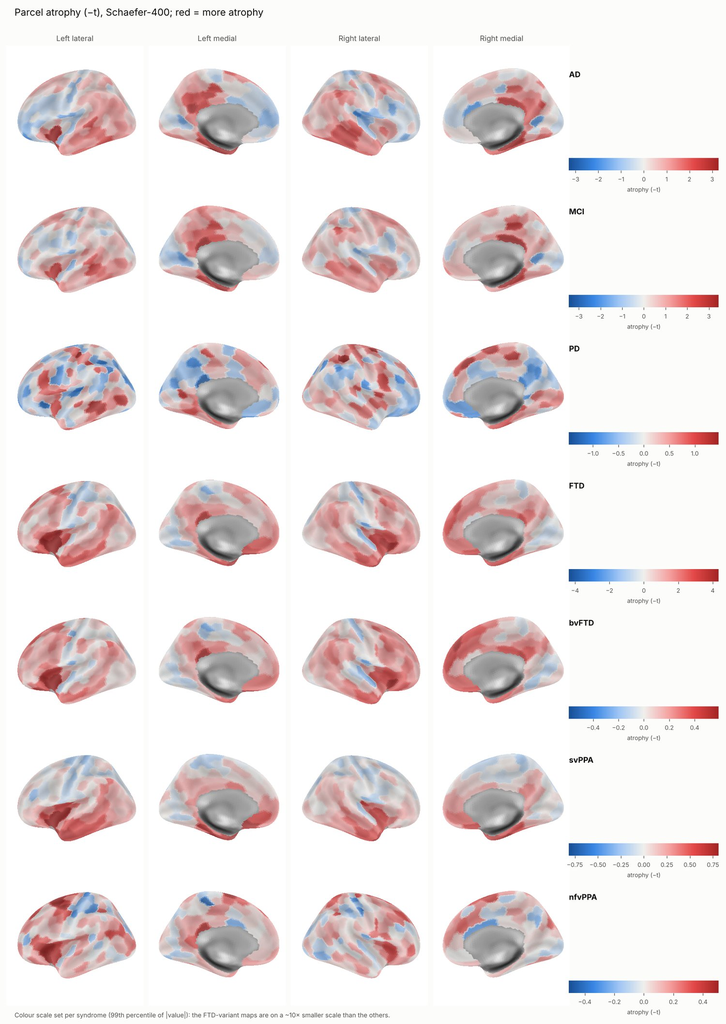

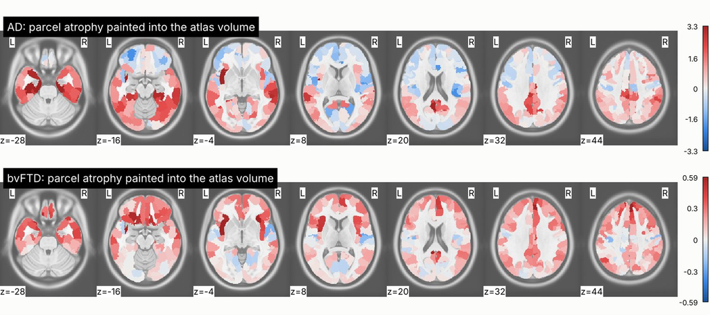

**Epicentres.** Epicentre score (mean rank of atrophy and SC-neighbour atrophy) and the top-10 parcels per syndrome (tables in “D. Epicentres”).

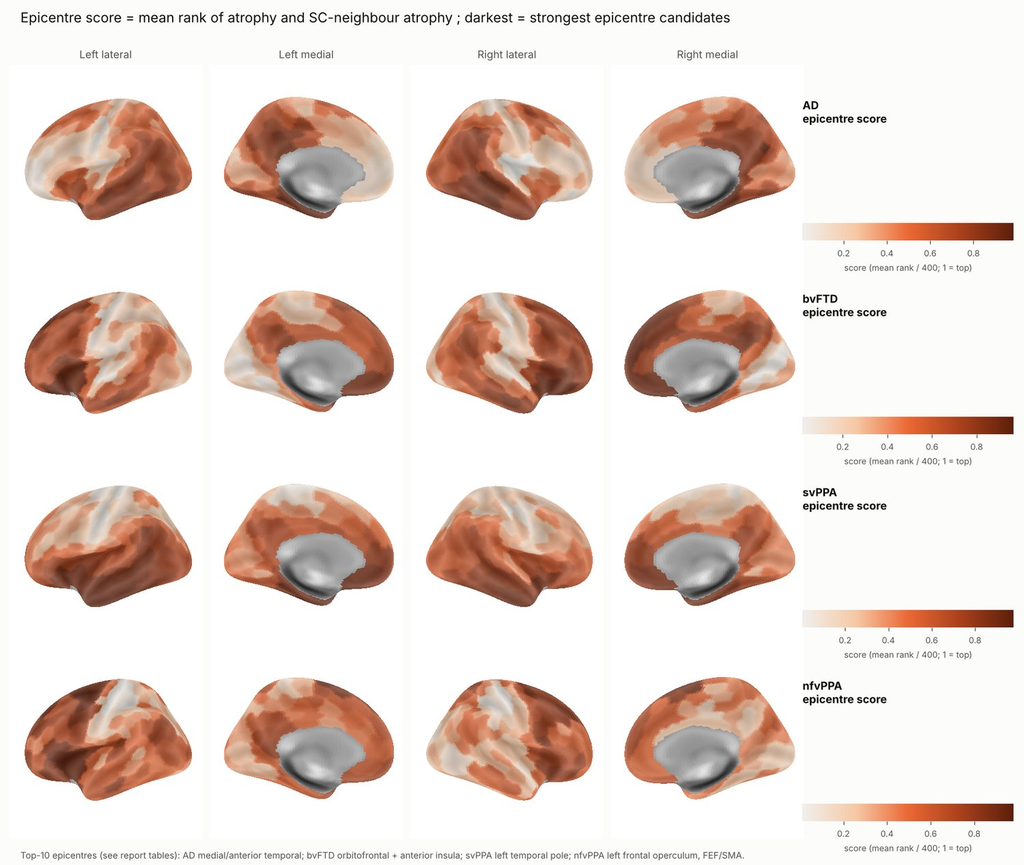

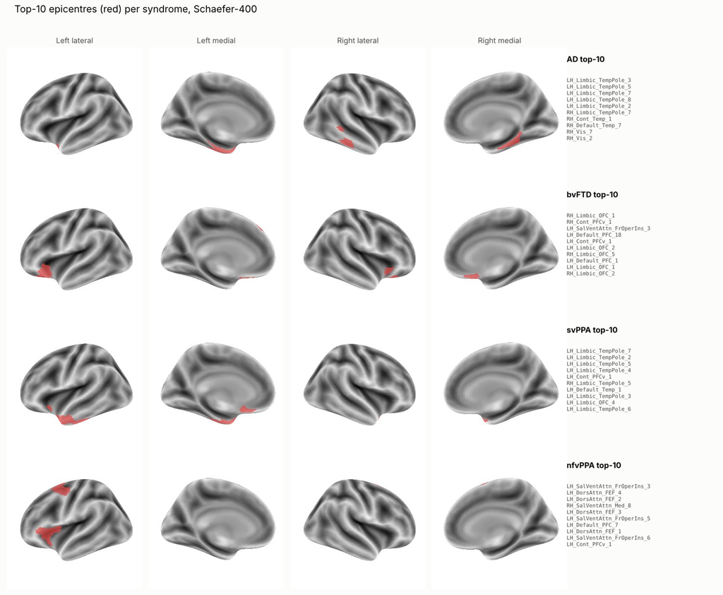

**Homotopic asymmetry.** Each left parcel compared with the identical region mirrored to the right (see “Hemispheric asymmetry”).

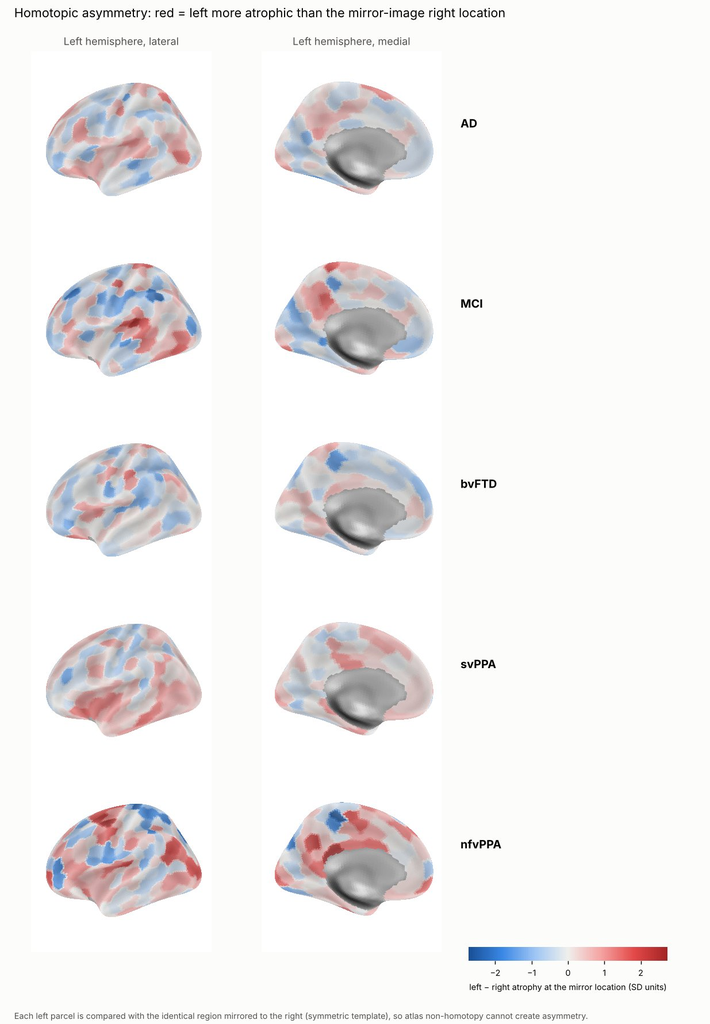

**Reconstruction from other regions.** Observed atrophy, its prediction from SC neighbours, FC neighbours and the distance kernel, and what is left after distance (and after distance + FC). In bvFTD the residual after distance still has frontal-insular structure that FC partly absorbs; in AD the distance prediction already captures most of the temporal–parietal pattern.

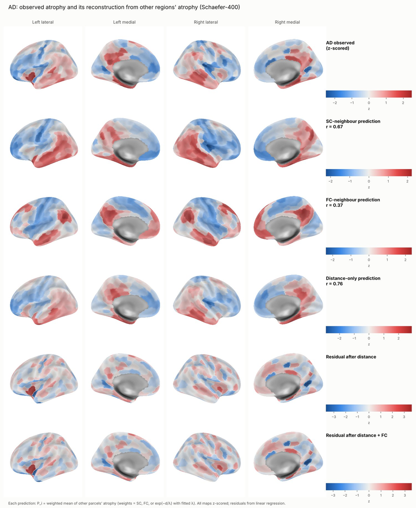

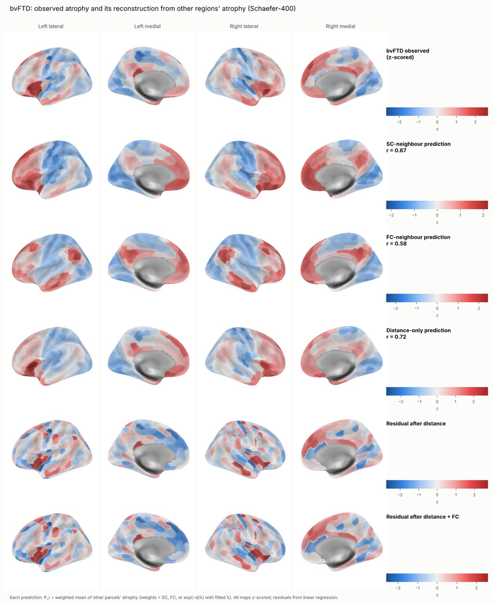

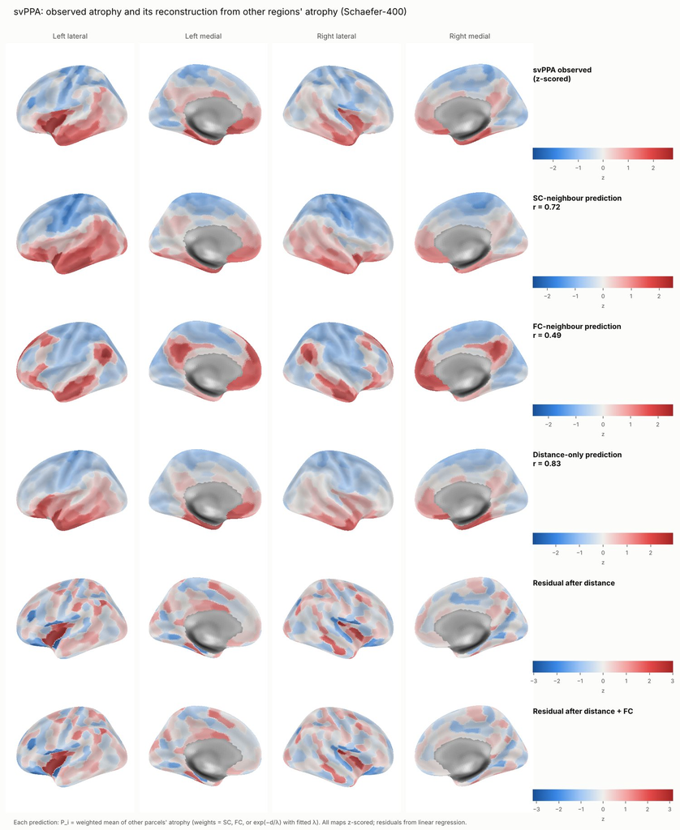

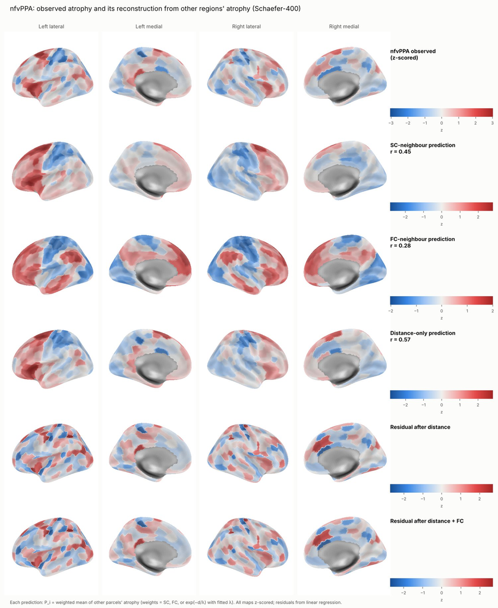

**Eigenmode reconstructions (K = 20)** and the first geometric eigenmodes themselves.

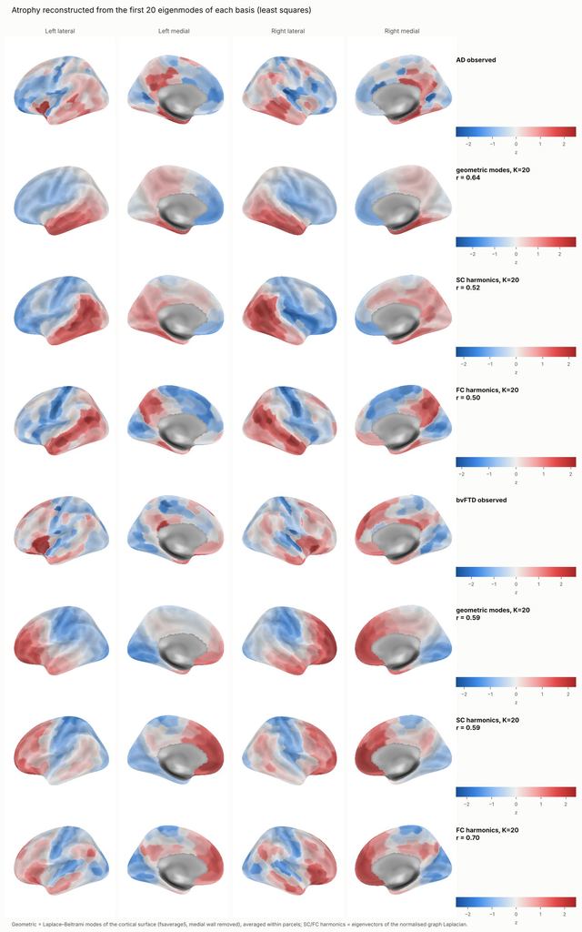

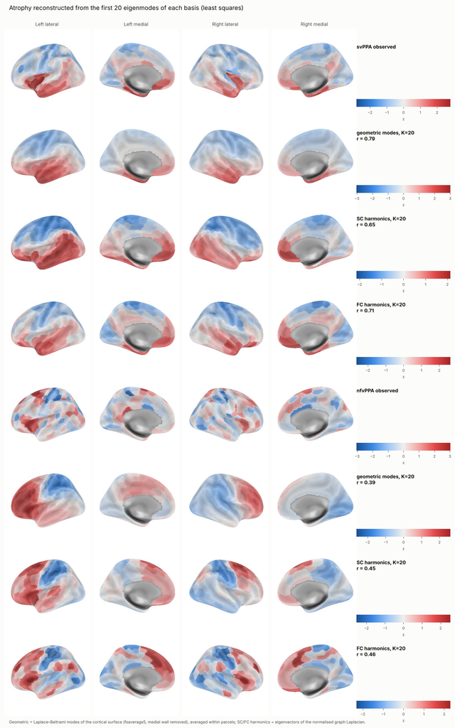

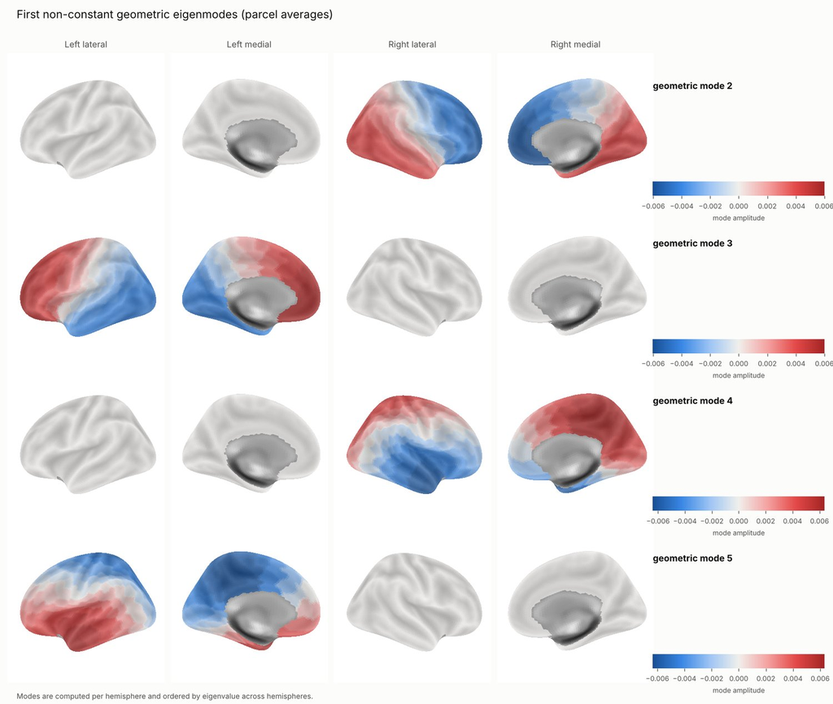

# 13 Novelty check

Searched on 2026-11-21: PubMed, Consensus (Semantic Scholar/OpenAlex/PubMed), a web search, and an Undermind deep search (102 papers ranked; workspace “Connectome-constrained atrophy: AD vs FTD (communication models)”). The closest papers were then read in full text.

**No study found compares structural-connectome communication models (shortest paths, communicability, search information, navigation, diffusion) head-to-head as predictors of atrophy in AD and the FTD variants, against a fitted distance-only baseline, with spatial and rewiring nulls.** The closest work:

[output not shown]

Less-applied methods used in the Extensions and their status in this literature:

- **Distance-censored prediction** (models allowed only to use parcels > R mm away): not found in the atrophy literature.
- **Comparison of five nulls** (spin, variogram-matched, Moran spectral, degree- and geometry-preserving rewiring) for network-constrained atrophy: the null-model literature compares spatial nulls for map-to-map correlations (Markello & Misic 2021, *NeuroImage*; Burt et al. 2020, *NeuroImage*), not for network-constrained atrophy. Shafiei et al. 2023 used a geometry-preserving rewired null, but only for a spreading simulation, not for the neighbour correlations or epicentres.
- **Geometric vs connectome eigenmodes for atrophy:** geometric eigenmodes have been used descriptively in GRN-related FTD (“mode-based morphometry”, *NeuroImage: Clinical* 2026); a head-to-head comparison with connectome harmonics across dementia syndromes was not found.
- **Atlas-induced laterality (mirror test):** not found.

Caveat: a search can miss work, especially recent preprints and conference abstracts. The claim is “not found in a systematic search”, not “does not exist”.

# 14 Limitations

- **Different cohorts and pipelines.** AD/MCI come from ADNI, PD from PPMI, and FTD and its variants from NIFD. Scanner, acquisition, age, disease stage and control group all differ between maps, so cohort effects are mixed with disease effects in any between-syndrome comparison. The three FTD-variant maps very likely share one NIFD control group, which inflates their mutual similarity (analysis A); spatial nulls do not correct for that. The variant maps also come from a later deposit with a different value scale.
- **Group-level maps.** One map per syndrome: no individual variability, no inference across patients; every test is across parcels.
- **Young-adult connectome.** HCP SC and FC come from healthy adults aged about 22–35.
- **Cortex only.** The Schaefer parcellation omits the hippocampus, amygdala and subcortex. ENIGMA provides HCP subcortical SC and FC for 14 structures (accumbens, amygdala, caudate, hippocampus, pallidum, putamen, thalamus, both sides) linked to Schaefer-400; adding them needs a matching volumetric subcortical atlas and the variogram or Moran nulls (spins do not apply to subcortex). For AD (hippocampus) and bvFTD and svPPA (amygdala, striatum, thalamus) the likely epicentres sit outside the parcellated cortex; cortical “epicentres” here are at best cortical entry points.
- **DBM signal.** DBM measures local volume change of the deformation, not grey matter; parcel means near CSF can include sulcal expansion, and depend on upstream smoothing.
- **Template mismatch and atlas asymmetry.** Atlas (FSL MNI152, asymmetric) and maps (ICBM 2009c, symmetric) differ, and Schaefer parcels are not left–right homotopic; “Laterality and the atlas” shows this creates spurious left-sided peaks.
- **Spatial nulls disagree.** Spin, variogram and Moran nulls give different p-values for the same statistic (see “Comparing null models”); the spin test can be liberal for smooth maps (Markello & Misic 2021). Conclusions rest on effects that survive the stricter nulls.
- **Geometry-preserving rewiring saturates** at about 50% edge turnover, so that null is closer to the empirical SC than the degree-preserving one by construction.
- **One fitted parameter for distance.** The distance kernel and heat kernel choose their parameter in-sample; refitting inside every null controls the inference, and the tuned-exponent sensitivity analysis gives the communication models the same freedom.
- **connectomeR not used.** The functions are project-level reimplementations validated against bctpy, netneurotools and neuromaps, not the package’s own (validated) versions. They should be cross-checked against `spin_test()`, `rotate_parcellation()` and `rewire_degree()` once the 0.2.0 source is available.
- **No DLB.** No DLB map exists in the two records, so Lewy body disease is not covered.

# 15 Reproducibility

```r
writeLines(readLines("output/pip_freeze.txt"))
```

```
## # python 3.13.18; venv used for bctpy/netneurotools/neuromaps references, annot_centroids.py and geometric_eigenmodes.py
## bctpy==0.6.1
## certifi==2026.11.20
## charset-normalizer==3.5.2
## cloudpickle==3.1.3
## contourpy==1.4.0
## cycler==0.12.1
## fonttools==4.68.0
## h5py==3.16.0
## idna==3.20
## Jinja2==3.1.6
## joblib==1.6.0
## kiwisolver==1.5.1
## MarkupSafe==3.0.4
## matplotlib==3.11.2
## narwhals==2.29.0
## netneurotools==0.3.0
## neuromaps==0.0.7
## nibabel==5.5.0
## nilearn==0.14.1
## numpy==2.5.5
## packaging==26.3
## pandas==3.1.1
## pillow==13.0.0
## pyparsing==3.3.3
## python-dateutil==4.0.0
## requests==2.34.2
## scikit-learn==1.9.1
## scipy==1.18.1
## threadpoolctl==3.8.0
## tqdm==4.70.1
## tzdata==2026.6
## urllib3==2.8.0
```